# IE 360 Homework 4 & 5

## ARIMAX Model

```r
facial_cleanser_xreg1<-cbind(facial_cleanser_daily_tr$favored_count,
                  facial_cleanser_daily_tr$basket_count,
                  facial_cleanser_daily_tr$category_sold,
                  facial_cleanser_daily_tr$is.discount_days,
                  facial_cleanser_daily_tr$visit_count)
facial_cleanser_xreg2<-cbind(facial_cleanser_daily_te$favored_count,
                  facial_cleanser_daily_te$basket_count,
                  facial_cleanser_daily_te$category_sold,
                  facial_cleanser_daily_te$is.discount_days,
                  facial_cleanser_daily_te$visit_count)

facial_cleanser_arimax<-Arima(facial_cleanser_ts_daily,xreg=as.matrix(facial_cleanser_xreg1),order=c(1,0,3))
facial_cleanser_daily_te$forecastarimax<-forecast(facial_cleanser_arimax,xreg=as.matrix(facial_cleanser_xreg2))$mean
error_test(facial_cleanser_daily_te$sold_count,facial_cleanser_daily_te$forecastarimax)
```

```
##    n     mean       sd        bias      mape      mad     wmape         MPE
## 1 11 71.54545 21.59335 -0.07684045 0.2303227 15.23747 0.2129761 -0.06672833
```

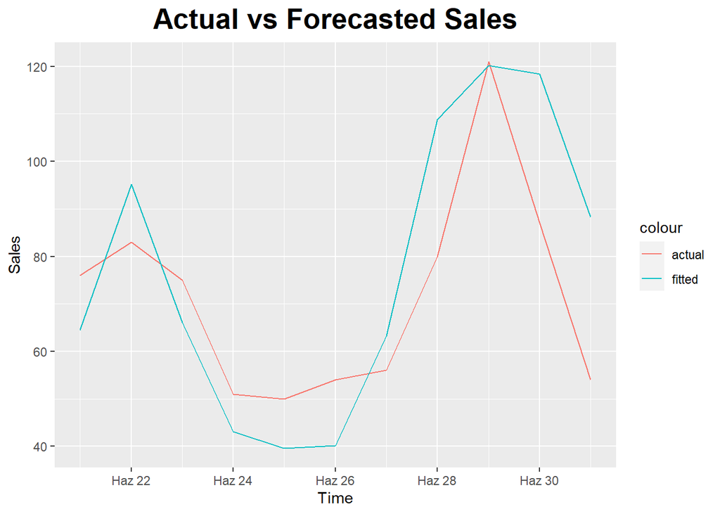

```r
ggplot(facial_cleanser_daily_te ,aes(x=event_date)) +
        geom_line(aes(y=sold_count,color='actual')) +
        geom_line(aes(y=forecastarimax,color='fitted')) + labs(title = "Actual vs Forecasted Sales",
       x = "Time",
       y = "Sales"
       )+
  theme(plot.title = element_text(color = "black", size = 20, face = "bold", hjust = 0.5),
        plot.subtitle = element_text(size = 10, face = "bold", hjust = 0.5),
        plot.caption = element_text(face = "italic", hjust = 0))
```

As can be seen from plot, actual and forecasted values are close to each other and WMAPE is low as desired. Facial cleanser sales count explained clearly with favored count, basket count, category sold, visit count and discount days.

# Sleepy Baby Wet Wipe

## Decomposition

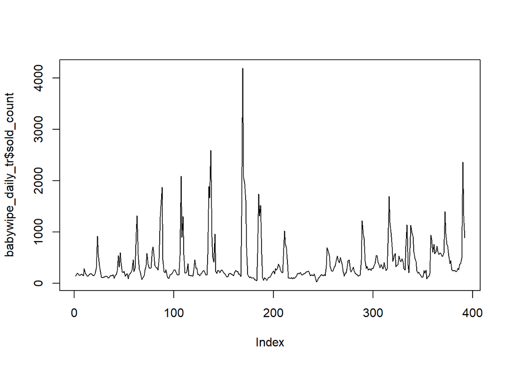

```r
babywipe<-subset(alldata, alldata$product_content_id==4066298)
babywipe_daily_tr<-babywipe[babywipe$event_date<"2021-06-21"]
babywipe_daily_te<-babywipe[babywipe$event_date>="2021-06-21"]
plot(babywipe_daily_tr$sold_count, type ='l')
```

The chart above shows a visualized version of the data. Looking at the graph, it can be said that there are outlier points and seasonality is visible.

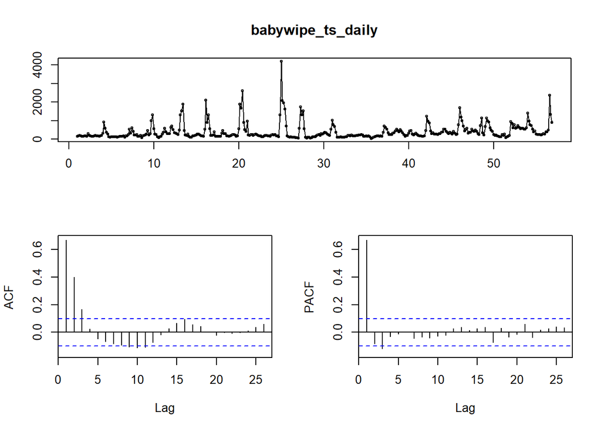

```r
babywipe_ts_daily<-ts(babywipe_daily_tr$sold_count, freq=7)
tsdisplay(babywipe_ts_daily)
```

In order to obtain a time series, necessary manipulations were made on the data. ACF plot shows significant correlation at lag 1,2 and 3, which shows that data has trend.

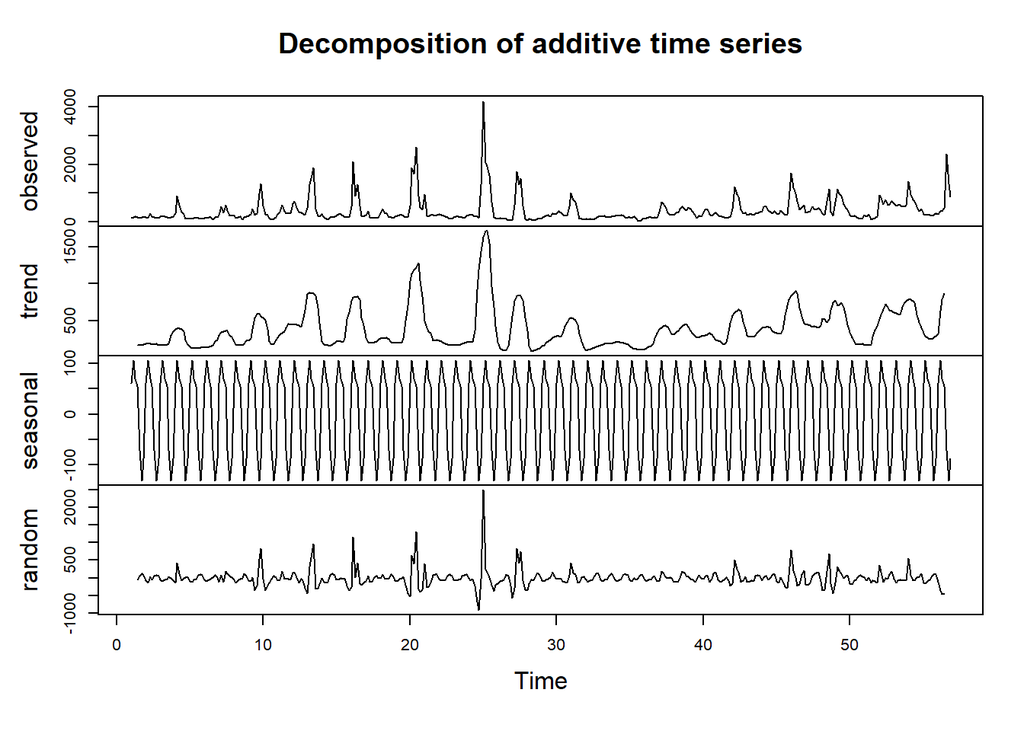

```r
babywipe_daily_additive<-decompose(babywipe_ts_daily, type ="additive")
babywipe_daily_multiplicative<-decompose(babywipe_ts_daily, type ="multiplicative")
plot(babywipe_daily_additive)
```

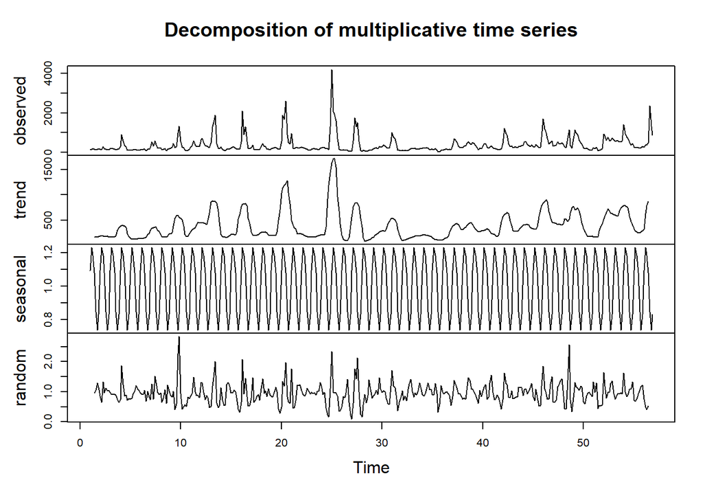

```r
plot(babywipe_daily_multiplicative)
```

The trend, seasonal and random graphs, which are formed when decomposed as additive and multiplicative, are shown above. Zero mean assumption looks like satisfied for both additive and multiplicative random parts. Neverthless, additive random part has visibly less variance compared to multiplicative random part.

In order to understand which model is better, the method to be used in the continuation of the study can be decided by applying specific tests that can measure stationarity for random part.

```r
test17=ur.kpss(babywipe_daily_additive$random, use.lag="7")
summary(test17)
```

```
##
## #######################
## # KPSS Unit Root Test #
## #######################
##
## Test is of type: mu with 7 lags.
##
## Value of test-statistic is: 0.0589
##
## Critical value for a significance level of:
##                 10pct  5pct 2.5pct  1pct
## critical values 0.347 0.463  0.574 0.739
```

```r
test18=ur.kpss(babywipe_daily_multiplicative$random, use.lag="7")
summary(test18)
```

```
##
## #######################
## # KPSS Unit Root Test #
## #######################
##
## Test is of type: mu with 7 lags.
##
## Value of test-statistic is: 0.0859
##
## Critical value for a significance level of:
##                 10pct  5pct 2.5pct  1pct
## critical values 0.347 0.463  0.574 0.739
```

The test-statistic for both decomposition method is smaller than the crucial value, indicating that we are unable to reject the null hypothesis. As a result, we can conclude the random data is stationary. However, additive decomposition has smaller test statistic. So, it should be used for further analysis.

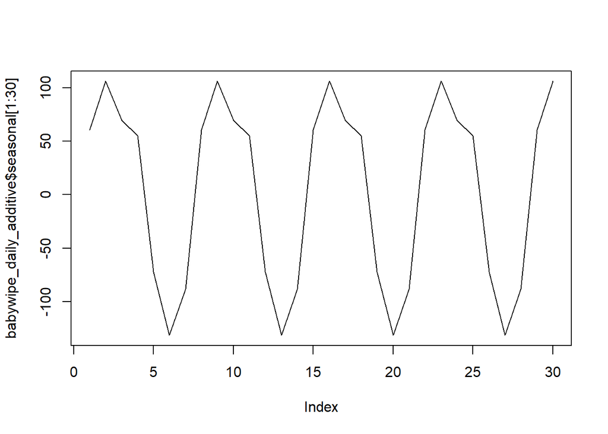

```r
plot(babywipe_daily_additive$seasonal[1:30], type='l')
```

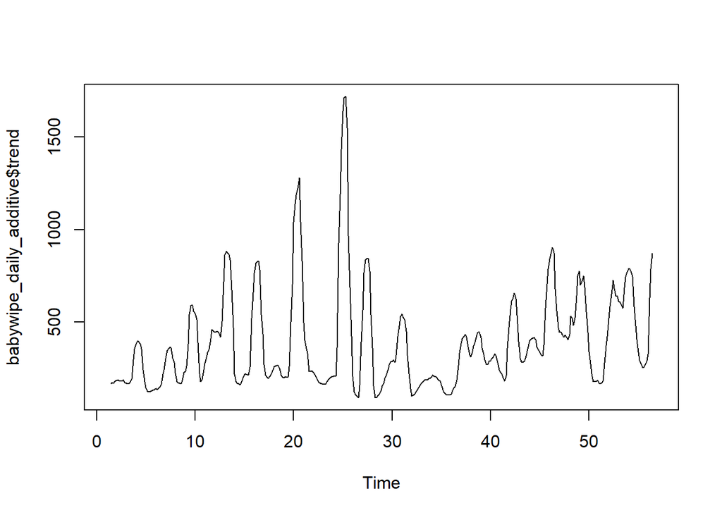

```r
plot(babywipe_daily_additive$trend, type='l')
```

Plots above show closer looks for trend and seasonal components of additive decomposition .

Since there are not enough data points, decomposition cannot made different levels. Altough we cannot decompose, weekly and monthly plots can be seen below.

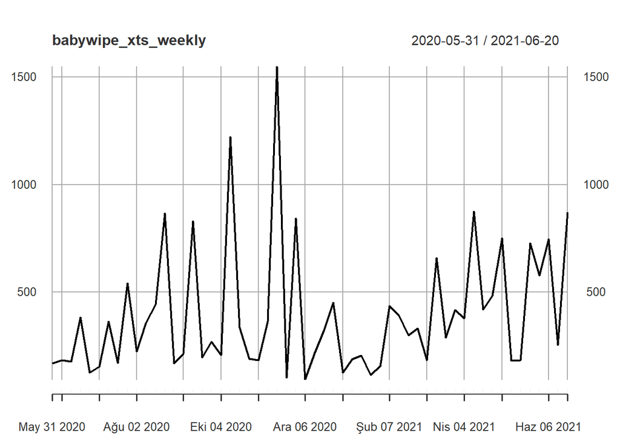

```r
babywipe_xts<-xts(babywipe_daily_tr$sold_count, order.by=as.Date(babywipe_daily_tr$event_date,"%d.%m.%Y"))
weekly<-endpoints(babywipe_xts,on="weeks")
babywipe_xts_weekly<-period.apply(babywipe_xts,INDEX=weekly,FUN=mean)
plot(babywipe_xts_weekly)
```

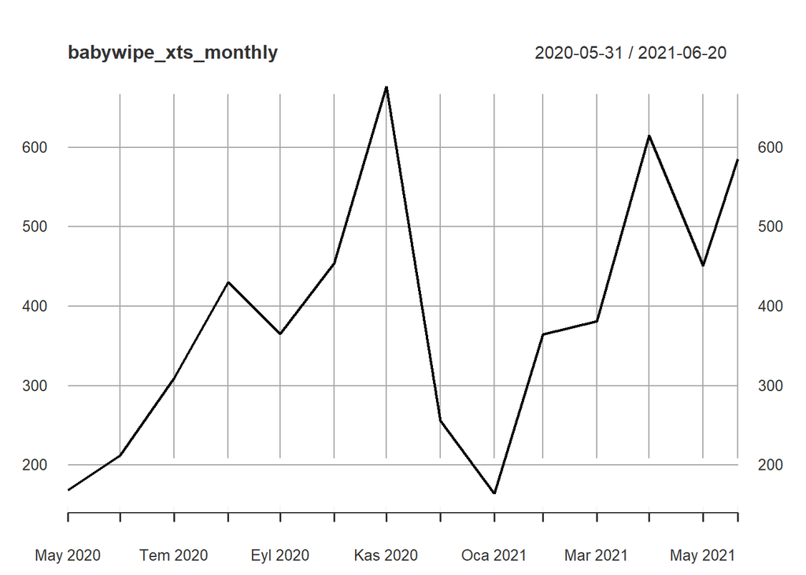

```r
monthly<-endpoints(babywipe_xts,on="months")
babywipe_xts_monthly<-period.apply(babywipe_xts,INDEX=monthly,FUN=mean)
plot(babywipe_xts_monthly)
```

Sales in November are influenced by discount days which are specified to get a better prediction outcome.

## ARIMA Model

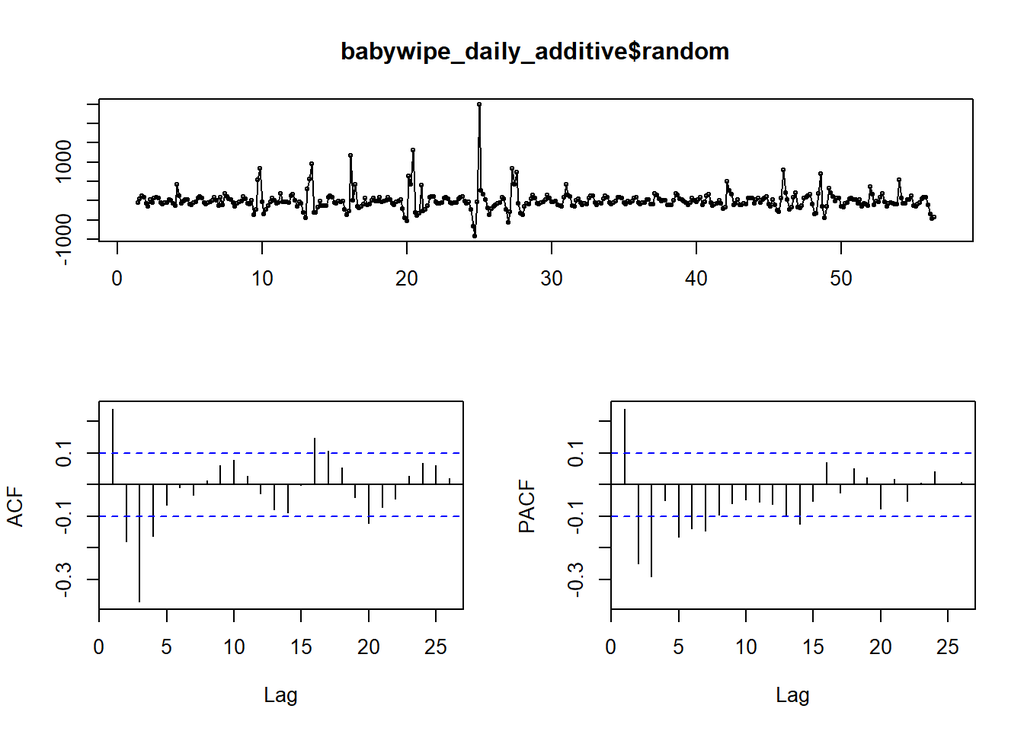

```r
tsdisplay(babywipe_daily_additive$random, na.action = na.omit)
```

According to ACF plot, there is significant negative correlation at lag 3. Hence, moving average parameter should be 3. Also, it can be seen from PACF plot that correlation significantly decreased after lag 3 which means that AR parameter should be 3.

```r
babywipe_model<-arima(babywipe_daily_additive$random, order = c(3,0,3))
AIC(babywipe_model)
```

```
## [1] 5217.269
```

```r
babywipe_model2<-arima(babywipe_daily_additive$random, order = c(2,0,3))
AIC(babywipe_model2)
```

```
## [1] 5194.018
```

```r
babywipe_model3<-arima(babywipe_daily_additive$random, order = c(1,0,3))
AIC(babywipe_model3)
```

```
## [1] 5227.107
```

Model 2 is better in terms of AIC values, therefore it is chosen.

Fitting the model

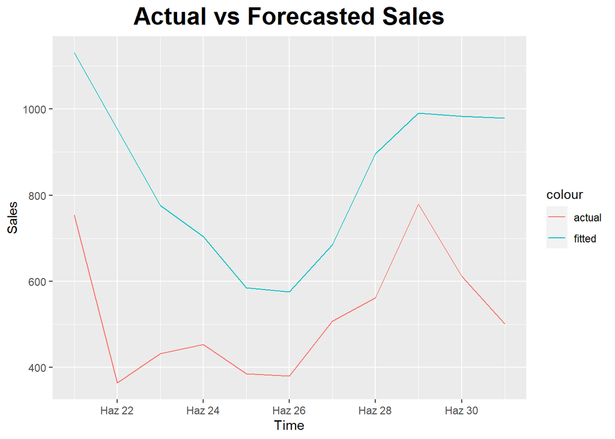

```r
model_forecast_error <- predict(babywipe_model2, n.ahead = 11)$pred
last_trend_value <-tail(babywipe_daily_additive$trend[!is.na(babywipe_daily_additive$trend)],1)
seasonality=babywipe_daily_additive$seasonal[295:305]
babywipe_arima_forecast=model_forecast_error+seasonality+last_trend_value

babywipe_daily_te$forecast<-paste(babywipe_arima_forecast)
babywipe_daily_te$forecast<-as.numeric(babywipe_daily_te$forecast)


ggplot(babywipe_daily_te ,aes(x=event_date)) +
        geom_line(aes(y=sold_count,color='actual')) +
        geom_line(aes(y=forecast,color='fitted')) + labs(title = "Actual vs Forecasted Sales",
       x = "Time",
       y = "Sales"
       )+
  theme(plot.title = element_text(color = "black", size = 20, face = "bold", hjust = 0.5),
        plot.subtitle = element_text(size = 10, face = "bold", hjust = 0.5),
        plot.caption = element_text(face = "italic", hjust = 0))
```

```r
error_test(babywipe_daily_te$sold_count,babywipe_daily_te$forecast)
```

```
##    n mean       sd      bias      mape      mad    wmape        MPE
## 1 11  521 143.7651 -0.615196 0.6609404 320.5171 0.615196 -0.6609404
```

WMAPE is 0.61. Model can be improved by adding regressor which will lower WMAPE.

## Regressor Search

```r
babywipe_lm1<-lm(sold_count~visit_count+is.discount_days, data=babywipe_daily_tr)
summary(babywipe_lm1)
```

```
##
## Call:
## lm(formula = sold_count ~ visit_count + is.discount_days, data = babywipe_daily_tr)
##
## Residuals:
##      Min       1Q   Median       3Q      Max
## -1104.11  -144.55   -81.80    28.45  2936.01
##
## Coefficients:
##                   Estimate Std. Error t value Pr(>|t|)
## (Intercept)      270.29626   20.64823   13.09  < 2e-16 ***
## visit_count        0.03880    0.00457    8.49  4.4e-16 ***
## is.discount_days 984.69064   92.35038   10.66  < 2e-16 ***
## ---
## Signif. codes:  0 '***' 0.001 '**' 0.01 '*' 0.05 '.' 0.1 ' ' 1
##
## Residual standard error: 350 on 389 degrees of freedom
## Multiple R-squared:  0.3374, Adjusted R-squared:  0.334
## F-statistic: 99.06 on 2 and 389 DF,  p-value: < 2.2e-16
```

```r
babywipe_lm2<-lm(sold_count~category_sold+price, data=babywipe_daily_tr)
summary(babywipe_lm2)
```

```
##
## Call:
## lm(formula = sold_count ~ category_sold + price, data = babywipe_daily_tr)
##
## Residuals:
##     Min      1Q  Median      3Q     Max
## -685.84  -76.99    8.36   80.37 1345.98
##
## Coefficients:
##                 Estimate Std. Error t value Pr(>|t|)
## (Intercept)   924.398434 194.061445   4.763 2.69e-06 ***
## category_sold   0.208919   0.006506  32.111  < 2e-16 ***
## price         -12.929247   2.651374  -4.876 1.58e-06 ***
## ---
## Signif. codes:  0 '***' 0.001 '**' 0.01 '*' 0.05 '.' 0.1 ' ' 1
##
## Residual standard error: 185.5 on 389 degrees of freedom
## Multiple R-squared:  0.8139, Adjusted R-squared:  0.813
## F-statistic: 850.8 on 2 and 389 DF,  p-value: < 2.2e-16
```

```r
babywipe_lm3<-lm(sold_count~price+favored_count+basket_count+category_sold, data=babywipe_daily_tr)
summary(babywipe_lm3)
```

```
##
## Call:
## lm(formula = sold_count ~ price + favored_count + basket_count +
##     category_sold, data = babywipe_daily_tr)
##
## Residuals:
##     Min      1Q  Median      3Q     Max
## -644.26  -41.18   10.37   48.97 1169.68
##
## Coefficients:
##                 Estimate Std. Error t value Pr(>|t|)
## (Intercept)    57.469328 124.209428   0.463    0.644
## price          -1.220304   1.695079  -0.720    0.472
## favored_count  -0.363498   0.023540 -15.442   <2e-16 ***
## basket_count    0.283905   0.011306  25.111   <2e-16 ***
## category_sold   0.113418   0.005918  19.163   <2e-16 ***
## ---
## Signif. codes:  0 '***' 0.001 '**' 0.01 '*' 0.05 '.' 0.1 ' ' 1
##
## Residual standard error: 114.1 on 387 degrees of freedom
## Multiple R-squared:   0.93,  Adjusted R-squared:  0.9293
## F-statistic:  1286 on 4 and 387 DF,  p-value: < 2.2e-16
```

```r
babywipe_lm4<-lm(sold_count~favored_count+basket_count+category_sold+is.discount_days, data=babywipe_daily_tr)
summary(babywipe_lm4)
```

```
##
## Call:
## lm(formula = sold_count ~ favored_count + basket_count + category_sold +
##     is.discount_days, data = babywipe_daily_tr)
##
## Residuals:
##     Min      1Q  Median      3Q     Max
## -740.20  -39.02   11.37   47.56 1125.06
##
## Coefficients:
##                    Estimate Std. Error t value Pr(>|t|)
## (Intercept)      -25.788167   8.588435  -3.003 0.002850 **
## favored_count     -0.351183   0.023274 -15.089  < 2e-16 ***
## basket_count       0.283635   0.010722  26.454  < 2e-16 ***
## category_sold      0.108112   0.005978  18.084  < 2e-16 ***
## is.discount_days 121.622410  33.420190   3.639 0.000311 ***
## ---
## Signif. codes:  0 '***' 0.001 '**' 0.01 '*' 0.05 '.' 0.1 ' ' 1
##
## Residual standard error: 112.2 on 387 degrees of freedom
## Multiple R-squared:  0.9322, Adjusted R-squared:  0.9315
## F-statistic:  1331 on 4 and 387 DF,  p-value: < 2.2e-16
```

```r
babywipe_daily_te$forecastlm1<-predict(babywipe_lm1,babywipe_daily_te)
babywipe_daily_te$forecastlm2<-predict(babywipe_lm2,babywipe_daily_te)
babywipe_daily_te$forecastlm3<-predict(babywipe_lm3,babywipe_daily_te)
babywipe_daily_te$forecastlm4<-predict(babywipe_lm4,babywipe_daily_te)

error_test(babywipe_daily_te$sold_count,babywipe_daily_te$forecastlm1)
```

```
##    n mean       sd         bias      mape      mad     wmape        MPE
## 1 11  521 143.7651 -0.007162319 0.1323333 62.80507 0.1205472 -0.0402405
```

```r
error_test(babywipe_daily_te$sold_count,babywipe_daily_te$forecastlm2)
```

```
##    n mean       sd       bias      mape      mad     wmape        MPE
## 1 11  521 143.7651 -0.4633883 0.4653101 241.4253 0.4633883 -0.4653101
```

```r
error_test(babywipe_daily_te$sold_count,babywipe_daily_te$forecastlm3)
```

```
##    n mean       sd       bias      mape      mad     wmape        MPE
## 1 11  521 143.7651 -0.2103372 0.2161906 109.5857 0.2103372 -0.2161906
```

```r
error_test(babywipe_daily_te$sold_count,babywipe_daily_te$forecastlm4)
```

```
##    n mean       sd       bias      mape      mad     wmape        MPE
## 1 11  521 143.7651 -0.1886224 0.1947759 98.27226 0.1886224 -0.1947759
```

## ARIMAX Model

```r
babywipe_xreg1<-cbind(babywipe_daily_tr$favored_count,
                  babywipe_daily_tr$basket_count,
                  babywipe_daily_tr$category_sold,
                  babywipe_daily_tr$is.discount_days)
babywipe_xreg2<-cbind(babywipe_daily_te$favored_count,
                  babywipe_daily_te$basket_count,
                  babywipe_daily_te$category_sold,
                  babywipe_daily_te$is.discount_days)

babywipe_arimax<-Arima(babywipe_ts_daily,xreg=as.matrix(babywipe_xreg1),order=c(2,0,3))
babywipe_daily_te$forecastarimax<-forecast(babywipe_arimax,xreg=as.matrix(babywipe_xreg2))$mean
error_test(babywipe_daily_te$sold_count,babywipe_daily_te$forecastarimax)
```

```
##    n mean       sd       bias     mape      mad    wmape        MPE
## 1 11  521 143.7651 -0.1168833 0.158371 85.02354 0.163193 -0.1031291
```

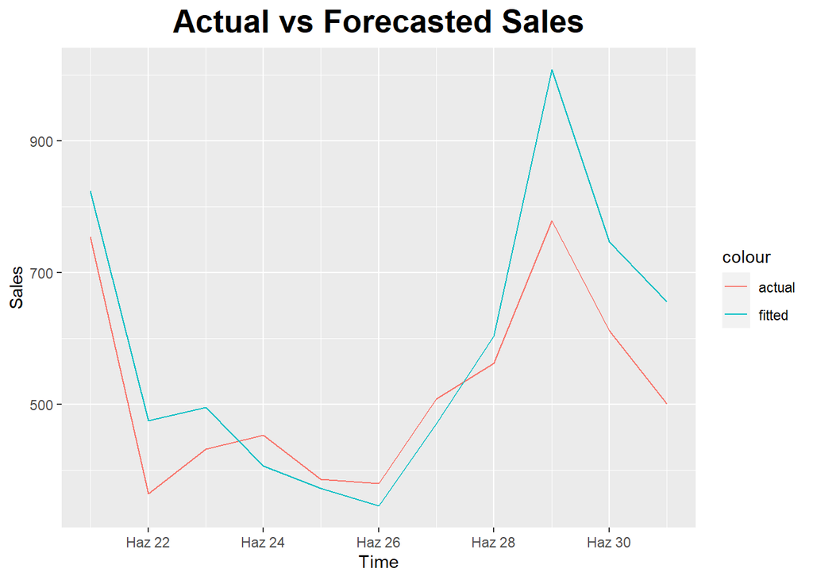

```r
ggplot(babywipe_daily_te ,aes(x=event_date)) +
        geom_line(aes(y=sold_count,color='actual')) +
        geom_line(aes(y=forecastarimax,color='fitted')) + labs(title = "Actual vs Forecasted Sales",
       x = "Time",
       y = "Sales"
       )+
  theme(plot.title = element_text(color = "black", size = 20, face = "bold", hjust = 0.5),
        plot.subtitle = element_text(size = 10, face = "bold", hjust = 0.5),
        plot.caption = element_text(face = "italic", hjust = 0))
```

As can be seen from plot, actual and forecasted values are close to each other and WMAPE is low as desired. Wet wipes sales count explained clearly with favored count, basket count, category sold and discount days.

# Altınyıldız Classics Coat

## Decomposition

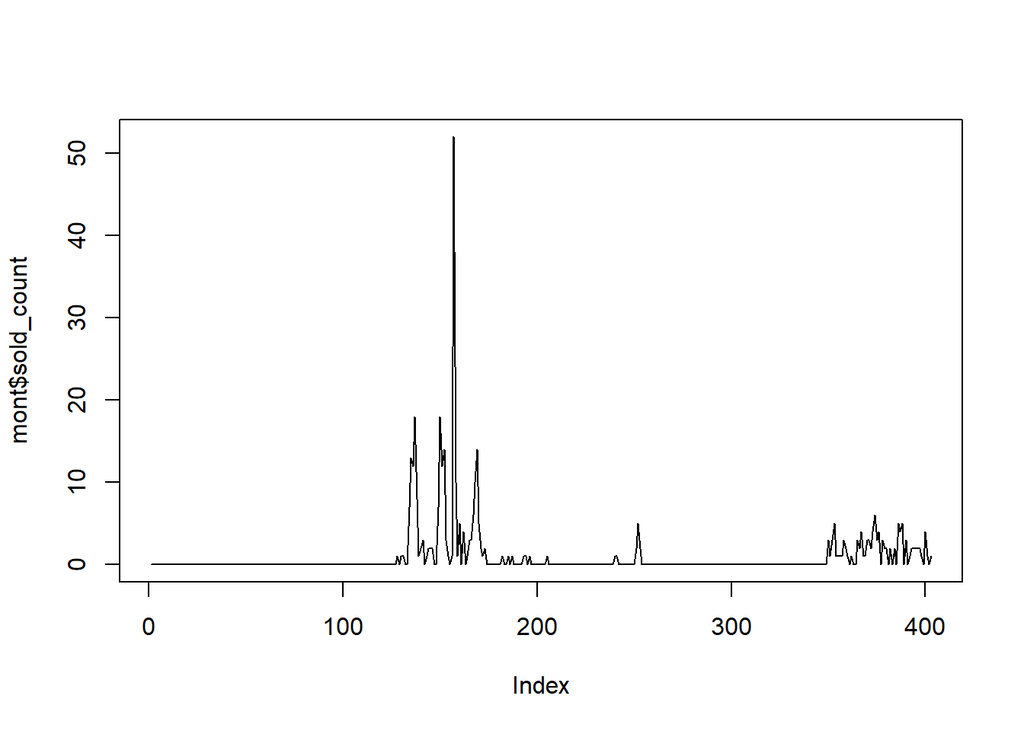

```r
mont<-subset(alldata, alldata$product_content_id==48740784)
#mont_xts<-xts(mont,order.by=mont$event_date)
mont_daily_tr<-mont[mont$event_date<"2021-06-21"]
mont_daily_te<-mont[mont$event_date>="2021-06-21"]
plot(mont$sold_count, type = 'l')
```

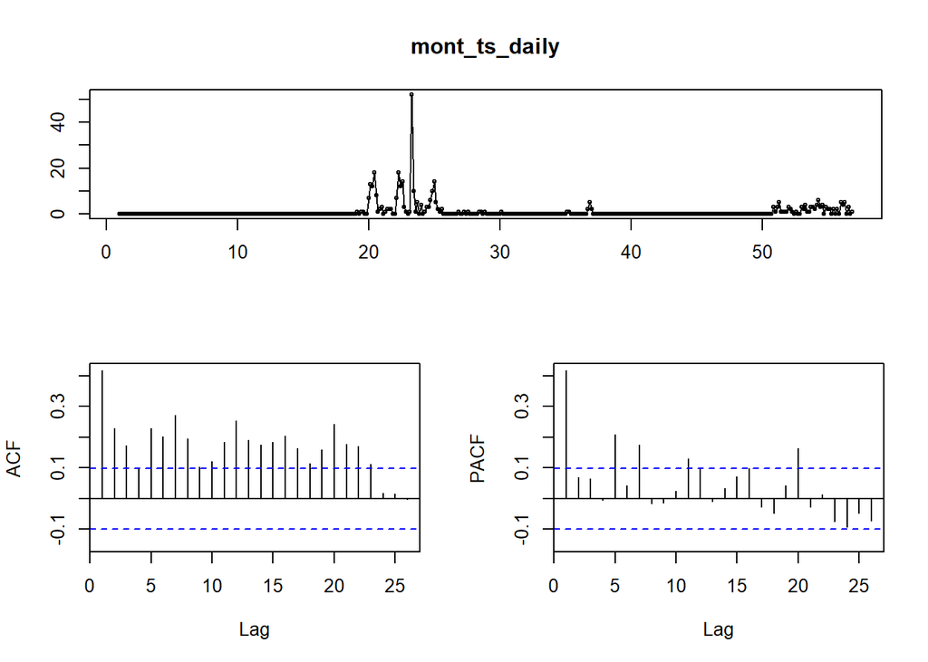

```r
mont_ts_daily<-ts(mont_daily_tr$sold_count, freq=7)
tsdisplay(mont_ts_daily)
```

Necessary data manipulations are made in order to construct a time series object with frequency 7. We see autocorrelation at lag 7 resulting that there is seasonality in weekly level. It will be examined further after decomposition.

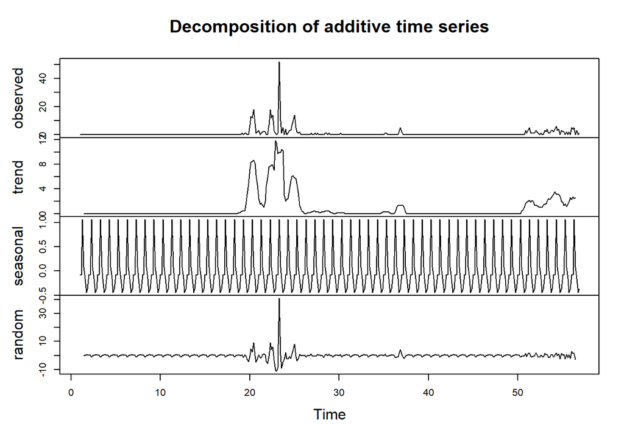

```r
mont_daily_additive<-decompose(mont_ts_daily, type ="additive")
mont_daily_multiplicative<-decompose(mont_ts_daily, type ="multiplicative")
plot(mont_daily_additive)
```

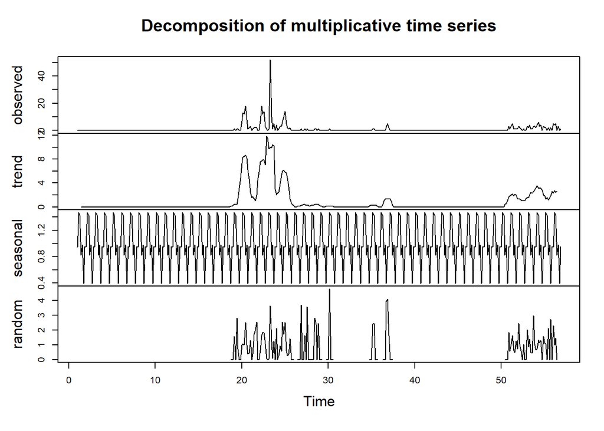

```r
plot(mont_daily_multiplicative)
```

Since the coat is not sold at certain months constant variance assumption is violated in both cases.

In order to understand which model is better, the method to be used in the continuation of the study can be decided by applying specific tests that can measure stationarity for random part.

```r
test1=ur.kpss(mont_daily_additive$random, use.lag="7")
summary(test1)
```

```
##
## #######################
## # KPSS Unit Root Test #
## #######################
##
## Test is of type: mu with 7 lags.
##
## Value of test-statistic is: 0.0104
##
## Critical value for a significance level of:
##                 10pct  5pct 2.5pct  1pct
## critical values 0.347 0.463  0.574 0.739
```

```r
test2=ur.kpss(mont_daily_multiplicative$random, use.lag="7")
summary(test2)
```

```
##
## #######################
## # KPSS Unit Root Test #
## #######################
##
## Test is of type: mu with 7 lags.
##
## Value of test-statistic is: 0.1086
##
## Critical value for a significance level of:
##                 10pct  5pct 2.5pct  1pct
## critical values 0.347 0.463  0.574 0.739
```

Test statistic of additive decomposition resulted better therefore it is chosen for further examinations.

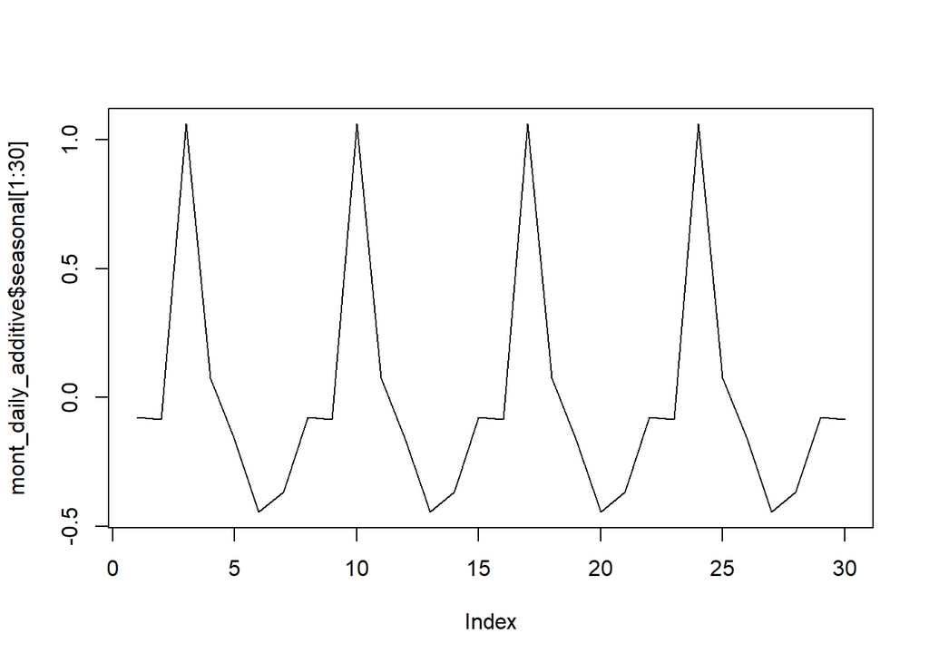

```r
plot(mont_daily_additive$seasonal[1:30], type='l')
```

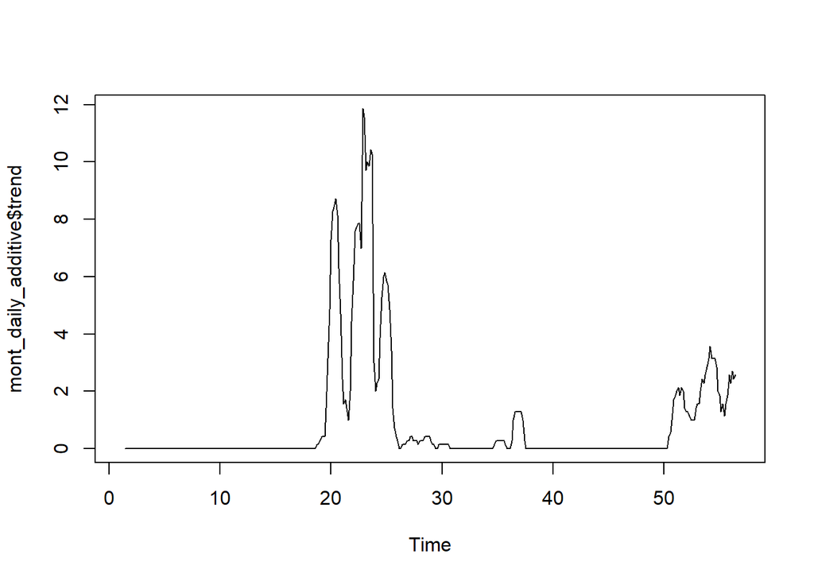

```r
plot(mont_daily_additive$trend, type='l')
```

Plots above show closer looks for trend and seasonal components of additive decomposition. We can clearly see a seasonality in daily level.

Since there are not enough data points, decomposition cannot made at different levels. Although we cannot decompose, weekly and monthly plots can be seen below.

Weekly

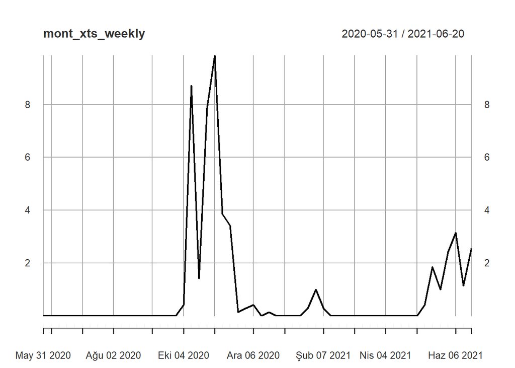

```r
mont_xts<-xts(mont_daily_tr$sold_count, order.by=as.Date(mont_daily_tr$event_date,"%d.%m.%Y"))
weekly<-endpoints(mont_xts,on="weeks")
mont_xts_weekly<-period.apply(mont_xts,INDEX=weekly,FUN=mean)
plot(mont_xts_weekly)
```

Monthly

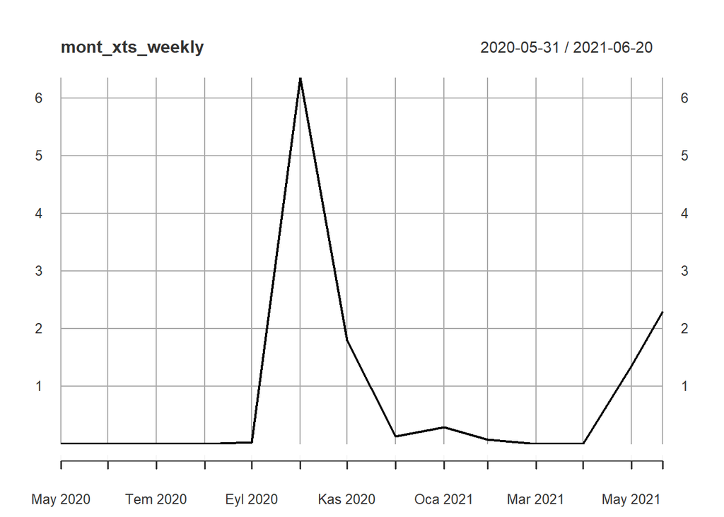

```r
mont_xts<-xts(mont_daily_tr$sold_count, order.by=as.Date(mont_daily_tr$event_date,"%d.%m.%Y"))
monthly<-endpoints(mont_xts,on="months")
mont_xts_weekly<-period.apply(mont_xts,INDEX=monthly,FUN=mean)
plot(mont_xts_weekly)
```

## ARIMA Model

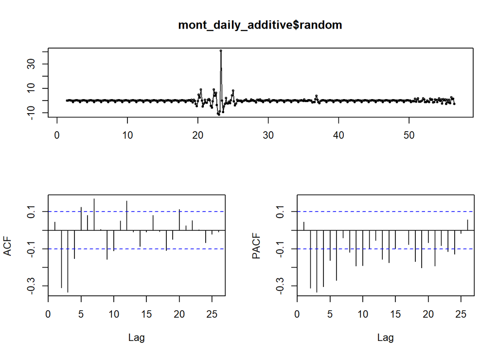

```r
tsdisplay(mont_daily_additive$random, na.action = na.omit)
```

```r
mont_model<-arima(mont_daily_additive$random, order = c(3,0,4))
summary(mont_model)
```

```
##
## Call:
## arima(x = mont_daily_additive$random, order = c(3, 0, 4))
##
## Coefficients:
##          ar1     ar2      ar3      ma1      ma2     ma3     ma4  intercept
##       0.2799  0.3529  -0.4270  -0.8088  -0.8964  0.5796  0.1256      0e+00
## s.e.  0.1689  0.1657   0.0903   0.1700   0.2437  0.0797  0.0797      4e-04
##
## sigma^2 estimated as 3.751:  log likelihood = -807.21,  aic = 1632.41
##
## Training set error measures:
##                      ME     RMSE       MAE      MPE     MAPE      MASE
## Training set 0.01248532 1.936705 0.7504695 86.26919 199.7648 0.6242751
##                     ACF1
## Training set 0.007485642
```

```r
mont_model2<-arima(mont_daily_additive$random, order = c(2,0,4))
AIC(mont_model2)
```

```
## [1] 1628.922
```

Model 2 is better in terms of AIC values, therefore it is chosen to perform the forecast.

Fitting the model

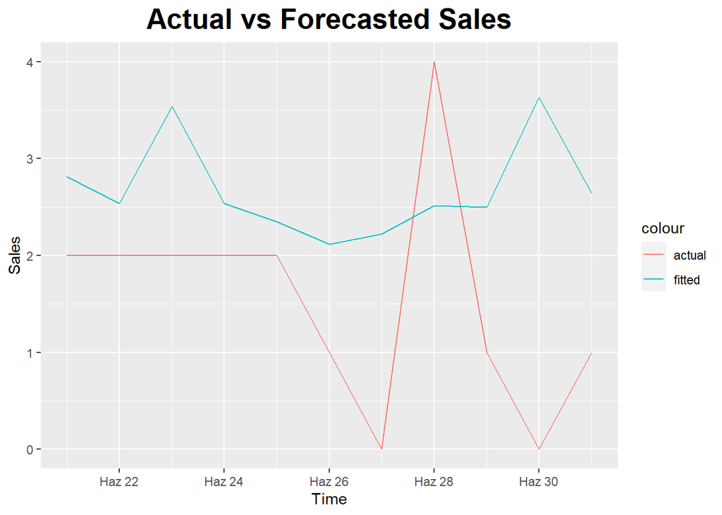

```r
model_forecast_error <- predict(mont_model2, n.ahead = 11)$pred
last_trend_value <-tail(mont_daily_additive$trend[!is.na(mont_daily_additive$trend)],1)
seasonality=mont_daily_additive$seasonal[295:305]
mont_arima_forecast=model_forecast_error+seasonality+last_trend_value

mont_daily_te$forecast<-paste(mont_arima_forecast)
mont_daily_te$forecast<-as.numeric(mont_daily_te$forecast)


ggplot(mont_daily_te ,aes(x=event_date)) +
        geom_line(aes(y=sold_count,color='actual')) +
        geom_line(aes(y=forecast,color='fitted')) + labs(title = "Actual vs Forecasted Sales",
       x = "Time",
       y = "Sales"
       )+
  theme(plot.title = element_text(color = "black", size = 20, face = "bold", hjust = 0.5),
        plot.subtitle = element_text(size = 10, face = "bold", hjust = 0.5),
        plot.caption = element_text(face = "italic", hjust = 0))
```

```r
error_test(mont_daily_te$sold_count,mont_daily_te$forecast)
```

```
##    n     mean       sd      bias mape      mad     wmape  MPE
## 1 11 1.545455 1.128152 -0.730025  Inf 1.397975 0.9045719 -Inf
```

In this case, the value of WMAPE turned out to be really high, because on some days the product is not available, and ARIMA could not predict whether the product would be sold

## Regressor Search

We constructed three different linear model and compared the wmape values to decide on the regressors that will be added to ARIMA model

```r
mont_lm1<-lm(sold_count~visit_count+is.discount_days, data=mont_daily_tr)
summary(mont_lm1)
```

```
##
## Call:
## lm(formula = sold_count ~ visit_count + is.discount_days, data = mont_daily_tr)
##
## Residuals:
##    Min     1Q Median     3Q    Max
## -2.329 -0.671 -0.663 -0.663 51.337
##
## Coefficients:
##                  Estimate Std. Error t value Pr(>|t|)
## (Intercept)      0.663459   0.189687   3.498 0.000524 ***
## visit_count      0.007301   0.002587   2.822 0.005016 **
## is.discount_days 1.592986   0.910109   1.750 0.080851 .
## ---
## Signif. codes:  0 '***' 0.001 '**' 0.01 '*' 0.05 '.' 0.1 ' ' 1
##
## Residual standard error: 3.448 on 389 degrees of freedom
## Multiple R-squared:  0.02602,    Adjusted R-squared:  0.02102
## F-statistic: 5.197 on 2 and 389 DF,  p-value: 0.005924
```

```r
mont_lm2<-lm(sold_count~category_sold+price, data=mont_daily_tr)
summary(mont_lm2)
```

```
##
## Call:
## lm(formula = sold_count ~ category_sold + price, data = mont_daily_tr)
##
## Residuals:
##    Min     1Q Median     3Q    Max
## -4.355 -2.910 -0.698  0.334 47.381
##
## Coefficients:
##                Estimate Std. Error t value Pr(>|t|)
## (Intercept)   0.5755049  1.3268375   0.434  0.66545
## category_sold 0.0001318  0.0008419   0.157  0.87594
## price         0.0056698  0.0021337   2.657  0.00923 **
## ---
## Signif. codes:  0 '***' 0.001 '**' 0.01 '*' 0.05 '.' 0.1 ' ' 1
##
## Residual standard error: 6.07 on 96 degrees of freedom
##   (293 observations deleted due to missingness)
## Multiple R-squared:  0.06883,    Adjusted R-squared:  0.04943
## F-statistic: 3.548 on 2 and 96 DF,  p-value: 0.03261
```

```r
mont_lm3<-lm(sold_count~favored_count+basket_count, data=mont_daily_tr)
summary(mont_lm3)
```

```
##
## Call:
## lm(formula = sold_count ~ favored_count + basket_count, data = mont_daily_tr)
##
## Residuals:
##      Min       1Q   Median       3Q      Max
## -13.6804   0.0378   0.1035   0.1035   9.8401
##
## Coefficients:
##                Estimate Std. Error t value Pr(>|t|)
## (Intercept)   -0.103516   0.085889  -1.205    0.229
## favored_count  0.003277   0.014855   0.221    0.826
## basket_count   0.171107   0.004247  40.291   <2e-16 ***
## ---
## Signif. codes:  0 '***' 0.001 '**' 0.01 '*' 0.05 '.' 0.1 ' ' 1
##
## Residual standard error: 1.527 on 389 degrees of freedom
## Multiple R-squared:  0.809,  Adjusted R-squared:  0.808
## F-statistic: 823.6 on 2 and 389 DF,  p-value: < 2.2e-16
```

```r
mont_daily_te$forecastlm1<-predict(mont_lm1,mont_daily_te)
mont_daily_te$forecastlm2<-predict(mont_lm2,mont_daily_te)
mont_daily_te$forecastlm3<-predict(mont_lm3,mont_daily_te)

error_test(mont_daily_te$sold_count,mont_daily_te$forecastlm1)
```

```
##    n     mean       sd       bias mape       mad     wmape  MPE
## 1 11 1.545455 1.128152 0.07639808  Inf 0.8102629 0.5242877 -Inf
```

```r
error_test(mont_daily_te$sold_count,mont_daily_te$forecastlm2)
```

```
##    n     mean       sd       bias mape     mad    wmape  MPE
## 1 11 1.545455 1.128152 -0.8498868  Inf 1.55831 1.008318 -Inf
```

```r
error_test(mont_daily_te$sold_count,mont_daily_te$forecastlm3)
```

```
##    n     mean       sd      bias mape       mad     wmape  MPE
## 1 11 1.545455 1.128152 0.5395895  Inf 0.9814649 0.6350655 -Inf
```

## ARIMAX Model

```r
mont_xreg1<-cbind(mont_daily_tr$is.discount_days,
                  mont_daily_tr$visit_count)
mont_xreg2<-cbind(mont_daily_te$is.discount_days,
                  mont_daily_te$visit_count)

mont_arimax<-Arima(mont_ts_daily,xreg=as.matrix(mont_xreg1),order=c(2,0,4))
mont_daily_te$forecastarimax<-forecast(mont_arimax,xreg=as.matrix(mont_xreg2))$mean
error_test(mont_daily_te$sold_count,mont_daily_te$forecastarimax)
```

```
##    n     mean       sd     bias mape       mad    wmape  MPE
## 1 11 1.545455 1.128152 0.160217  Inf 0.8518484 0.551196 -Inf
```

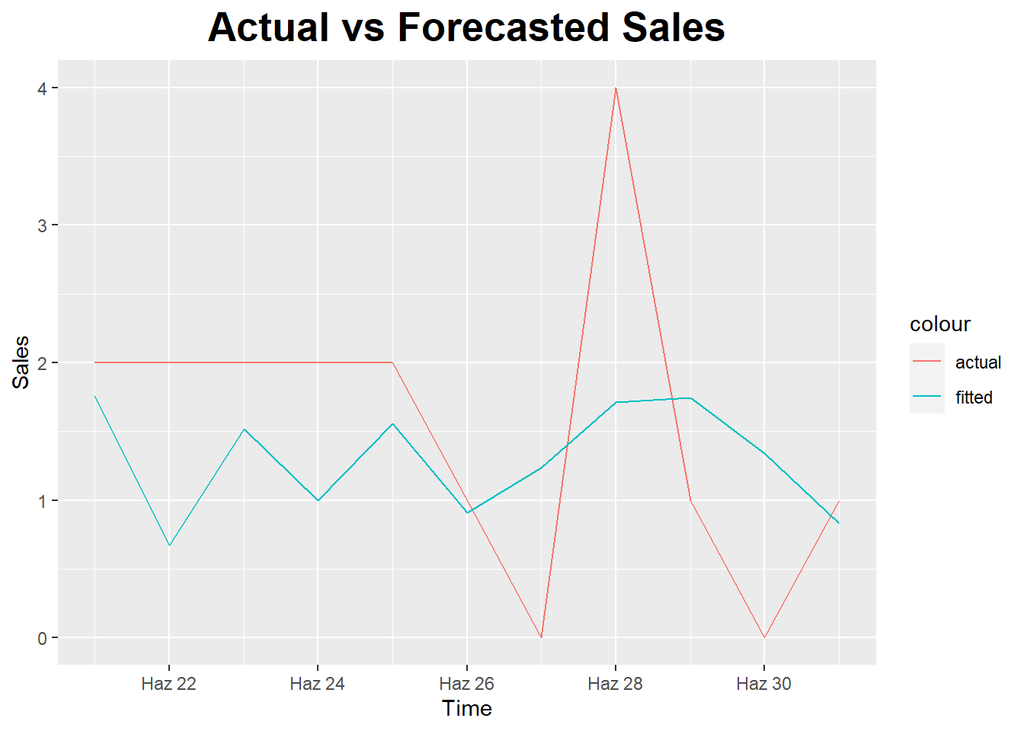

```r
ggplot(mont_daily_te ,aes(x=event_date)) +
        geom_line(aes(y=sold_count,color='actual')) +
        geom_line(aes(y=forecastarimax,color='fitted')) + labs(title = "Actual vs Forecasted Sales",
       x = "Time",
       y = "Sales"
       )+
  theme(plot.title = element_text(color = "black", size = 20, face = "bold", hjust = 0.5),
        plot.subtitle = element_text(size = 10, face = "bold", hjust = 0.5),
        plot.caption = element_text(face = "italic", hjust = 0))
```

Above plot shows the forecasted and actual values with the ARIMAX model. Model significantly improved with the addition of regressors.

# Oral-B Toothbrush

## Decomposition

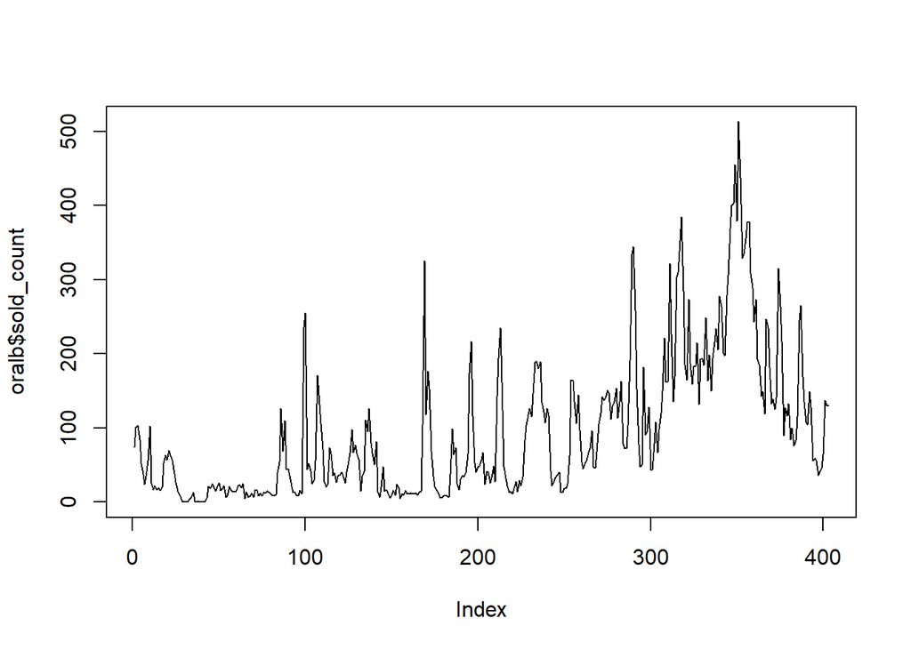

```r
oralb<-subset(alldata, alldata$product_content_id==32939029)
#oralb_xts<-xts(oralb,order.by=oralb$event_date)
oralb_daily_tr<-oralb[oralb$event_date<"2021-06-21"]
oralb_daily_te<-oralb[oralb$event_date>="2021-06-21"]
plot(oralb$sold_count, type='l')
```

Plot above shows sold counts of Oral-B Toothbrush. Variance seems increasing and also sales are increasing over time.

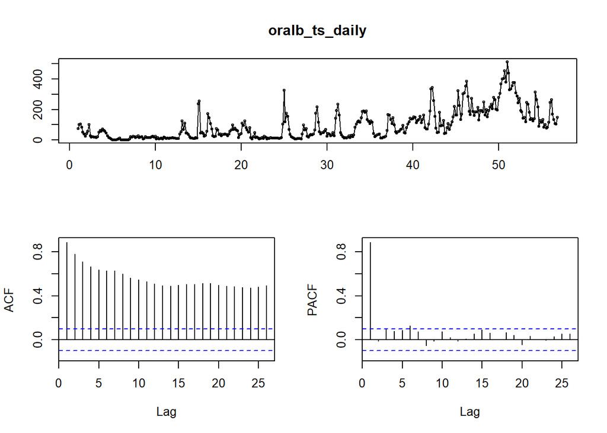

```r
oralb_ts_daily<-ts(oralb_daily_tr$sold_count, freq=7)
tsdisplay(oralb_ts_daily)
```

Necessary data manipulations are made in order to obtain daily data. ACF plot shows high correlation and PACF shows only significant correlation at lag 1. It will be examined further after decomposition.

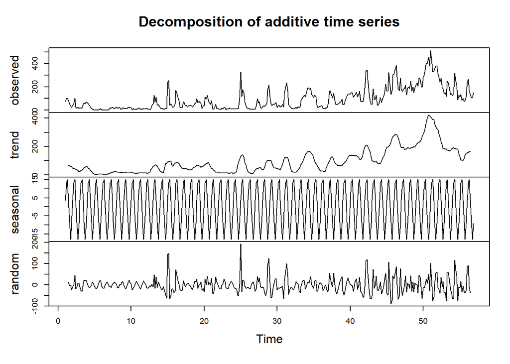

```r
oralb_daily_additive<-decompose(oralb_ts_daily, type ="additive")
oralb_daily_multiplicative<-decompose(oralb_ts_daily, type ="multiplicative")
plot(oralb_daily_additive)
```

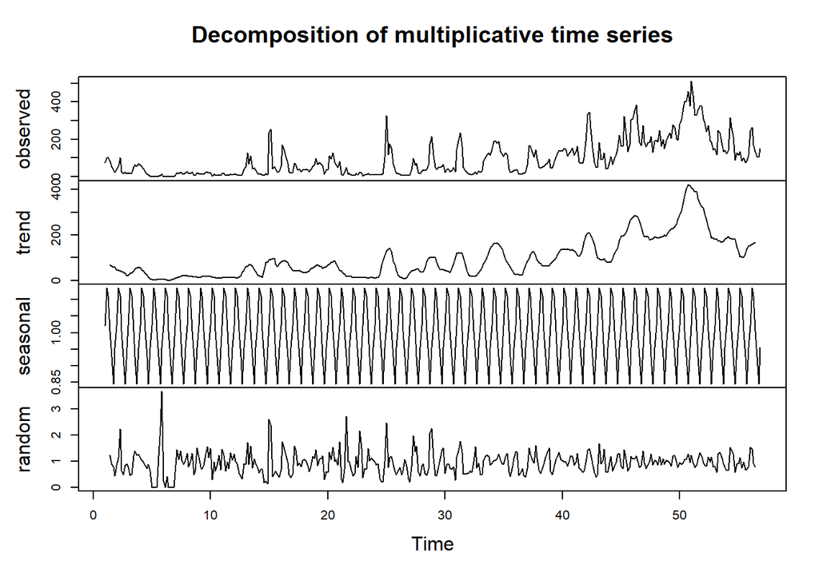

```r
plot(oralb_daily_multiplicative)
```

For additive decomposition random part has increasing variance, which does not satisfy constants variance assumption.For multiplicative decomposition random part has decreasing variance, which does not satisfy constants variance assumption as well.

In order to understand which model is better, the method to be used in the continuation of the study can be decided by applying specific tests that can measure stationarity for random part.

```r
test1=ur.kpss(oralb_daily_additive$random, use.lag="7")
summary(test1)
```

```
##
## #######################
## # KPSS Unit Root Test #
## #######################
##
## Test is of type: mu with 7 lags.
##
## Value of test-statistic is: 0.0132
##
## Critical value for a significance level of:
##                 10pct  5pct 2.5pct  1pct
## critical values 0.347 0.463  0.574 0.739
```

```r
test2=ur.kpss(oralb_daily_multiplicative$random, use.lag="7")
summary(test2)
```

```
##
## #######################
## # KPSS Unit Root Test #
## #######################
##
## Test is of type: mu with 7 lags.
##
## Value of test-statistic is: 0.3125
##
## Critical value for a significance level of:
##                 10pct  5pct 2.5pct  1pct
## critical values 0.347 0.463  0.574 0.739
```

Test statistic of additive decomposition resulted better therefore it is chosen for further examinations.

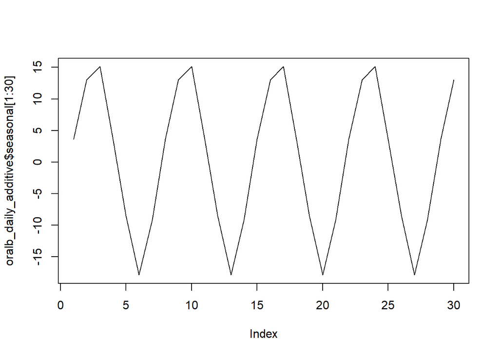

```r
plot(oralb_daily_additive$seasonal[1:30], type='l')
```

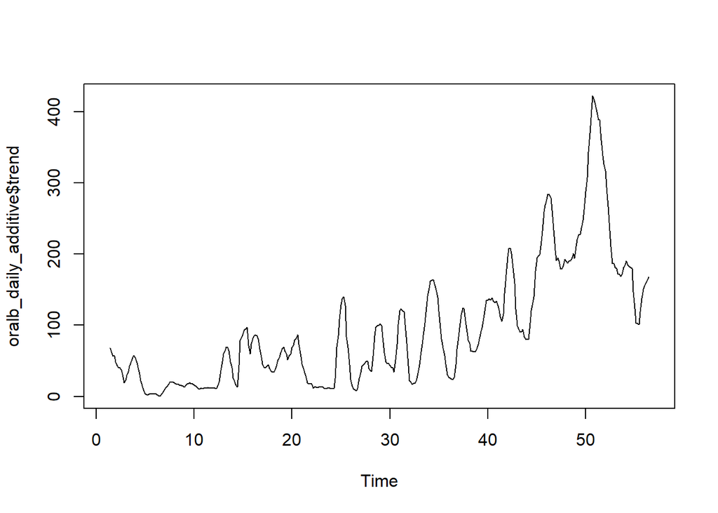

```r
plot(oralb_daily_additive$trend, type='l')
```

Plots above show closer looks for trend and seasonal components of additive decomposition. We can clearly see a seasonality in daily level.

Since there are not enough data points, decomposition cannot made different levels. Altough we cannot decompose, weekly and monthly plots can be seen below.

Weekly

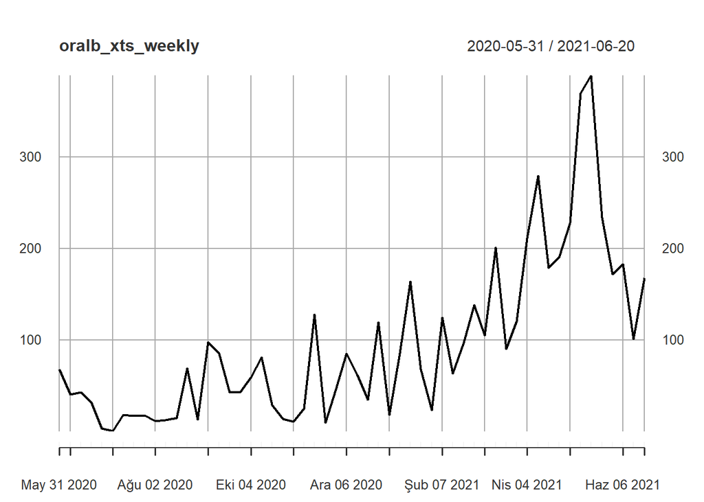

```r
oralb_xts<-xts(oralb_daily_tr$sold_count, order.by=as.Date(oralb_daily_tr$event_date,"%d.%m.%Y"))
weekly<-endpoints(oralb_xts,on="weeks")
oralb_xts_weekly<-period.apply(oralb_xts,INDEX=weekly,FUN=mean)
plot(oralb_xts_weekly)
```

Monthly

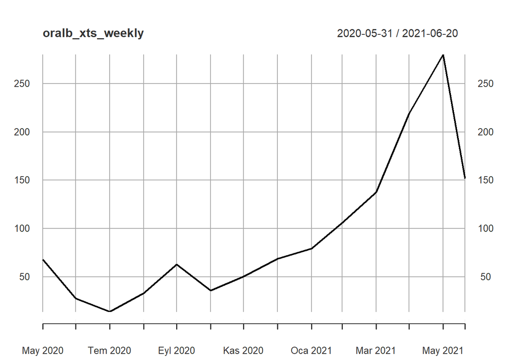

```r
oralb_xts<-xts(oralb_daily_tr$sold_count, order.by=as.Date(oralb_daily_tr$event_date,"%d.%m.%Y"))
monthly<-endpoints(oralb_xts,on="months")
oralb_xts_weekly<-period.apply(oralb_xts,INDEX=monthly,FUN=mean)
plot(oralb_xts_weekly)
```

Weekly and monthly plots shows demand for such product increased over time. Even so, there are still outlier weeks and months that cannot be explained with only sold item count. Price or promotions may affect such outlier points.

## ARIMA Model

To decide on the parameters of ARIMA model, autocorrelation and partial autocorrelation of the random component of additive model are investigated.

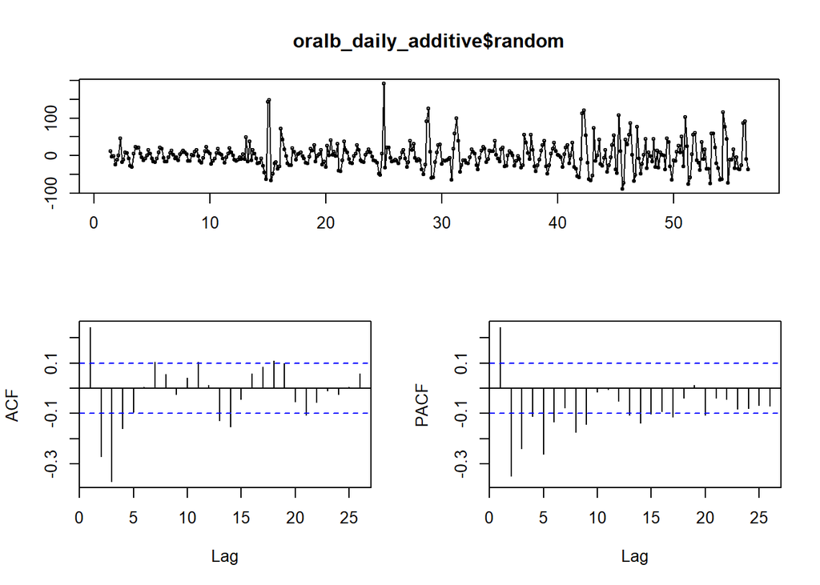

```r
tsdisplay(oralb_daily_additive$random, na.action = na.omit)
```

```r
oralb_model<-arima(oralb_daily_additive$random, order = c(3,0,3))
summary(oralb_model)
```

```
##
## Call:
## arima(x = oralb_daily_additive$random, order = c(3, 0, 3))
##
## Coefficients:
##          ar1     ar2      ar3      ma1      ma2      ma3  intercept
##       0.2399  0.0993  -0.2964  -0.2553  -0.6100  -0.1347    -0.0024
## s.e.  0.2453  0.2464   0.1538   0.2488   0.2466   0.1419     0.0251
##
## sigma^2 estimated as 787.9:  log likelihood = -1837.79,  aic = 3691.58
##
## Training set error measures:
##                      ME     RMSE      MAE      MPE     MAPE      MASE
## Training set -0.4667117 28.07005 19.36278 49.37787 226.8666 0.6808855
##                      ACF1
## Training set -0.005579994
```

As can be seen from the graphs there is significant negative autocorrelation in lag 3 at ACF and partial autocorrelation decreased significantly after lag 3 in PACF therefore parameters would be selected as (3,0,3)

```r
oralb_model2<-arima(oralb_daily_additive$random, order = c(2,0,3))
AIC(oralb_model2)
```

```
## [1] 3690.505
```

Model 2 is better in terms of AIC values, therefore it is chosen to construct the ARIMA model

Fitting the model

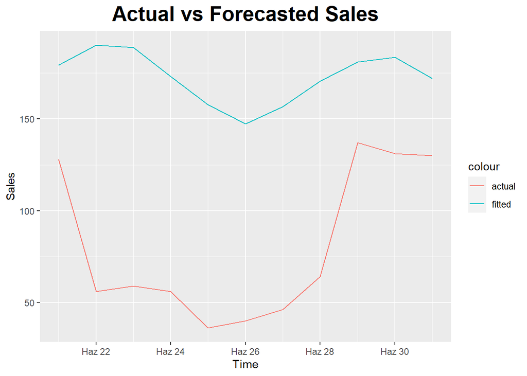

```r
model_forecast_error <- predict(oralb_model2, n.ahead = 11)$pred
last_trend_value <-tail(oralb_daily_additive$trend[!is.na(oralb_daily_additive$trend)],1)
seasonality=oralb_daily_additive$seasonal[295:305]
oralb_arima_forecast=model_forecast_error+seasonality+last_trend_value

oralb_daily_te$forecast<-paste(oralb_arima_forecast)
oralb_daily_te$forecast<-as.numeric(oralb_daily_te$forecast)


ggplot(oralb_daily_te ,aes(x=event_date)) +
        geom_line(aes(y=sold_count,color='actual')) +
        geom_line(aes(y=forecast,color='fitted')) + labs(title = "Actual vs Forecasted Sales",
       x = "Time",
       y = "Sales"
       )+
  theme(plot.title = element_text(color = "black", size = 20, face = "bold", hjust = 0.5),
        plot.subtitle = element_text(size = 10, face = "bold", hjust = 0.5),
        plot.caption = element_text(face = "italic", hjust = 0))
```

From above plot, it can be seen that we are overpredicting, it is mainly due to the constant trend assumption, with the addition of regressors this bias may be decreased.

```r
error_test(oralb_daily_te$sold_count,oralb_daily_te$forecast)
```

```
##    n     mean       sd      bias     mape      mad    wmape       MPE
## 1 11 80.27273 41.46587 -1.153151 1.661979 92.56657 1.153151 -1.661979
```

WMAPE value is too much in this case because of the reasons mentioned above.

## Regressor Search

To decide on which regressors to use, 3 different linear models are constructed and compared in terms of their error rates.

```r
oralb_lm1<-lm(sold_count~visit_count+is.discount_days, data=oralb_daily_tr)
summary(oralb_lm1)
```

```
##
## Call:
## lm(formula = sold_count ~ visit_count + is.discount_days, data = oralb_daily_tr)
##
## Residuals:
##     Min      1Q  Median      3Q     Max
## -124.33  -29.55  -16.55   15.01  235.86
##
## Coefficients:
##                   Estimate Std. Error t value Pr(>|t|)
## (Intercept)      4.055e+01  3.156e+00  12.849  < 2e-16 ***
## visit_count      2.343e-02  7.527e-04  31.134  < 2e-16 ***
## is.discount_days 4.858e+01  1.371e+01   3.543 0.000443 ***
## ---
## Signif. codes:  0 '***' 0.001 '**' 0.01 '*' 0.05 '.' 0.1 ' ' 1
##
## Residual standard error: 52.01 on 389 degrees of freedom
## Multiple R-squared:  0.7192, Adjusted R-squared:  0.7178
## F-statistic: 498.2 on 2 and 389 DF,  p-value: < 2.2e-16
```

```r
oralb_lm2<-lm(sold_count~category_sold+price, data=oralb_daily_tr)
summary(oralb_lm2)
```

```
##
## Call:
## lm(formula = sold_count ~ category_sold + price, data = oralb_daily_tr)
##
## Residuals:
##     Min      1Q  Median      3Q     Max
## -242.52  -56.85  -26.14   36.76  380.15
##
## Coefficients:
##                 Estimate Std. Error t value Pr(>|t|)
## (Intercept)   -2.950e+02  6.511e+01  -4.531 7.86e-06 ***
## category_sold  5.331e-02  5.824e-03   9.154  < 2e-16 ***
## price          2.501e+00  4.721e-01   5.297 2.00e-07 ***
## ---
## Signif. codes:  0 '***' 0.001 '**' 0.01 '*' 0.05 '.' 0.1 ' ' 1
##
## Residual standard error: 87.45 on 380 degrees of freedom
##   (9 observations deleted due to missingness)
## Multiple R-squared:  0.2068, Adjusted R-squared:  0.2026
## F-statistic: 49.54 on 2 and 380 DF,  p-value: < 2.2e-16
```

```r
oralb_lm3<-lm(sold_count~favored_count+basket_count, data=oralb_daily_tr)
summary(oralb_lm3)
```

```
##
## Call:
## lm(formula = sold_count ~ favored_count + basket_count, data = oralb_daily_tr)
##
## Residuals:
##      Min       1Q   Median       3Q      Max
## -182.608  -10.381   -3.624    7.994  115.926
##
## Coefficients:
##                Estimate Std. Error t value Pr(>|t|)
## (Intercept)    3.070275   2.068327   1.484    0.139
## favored_count -0.036779   0.006199  -5.933 6.59e-09 ***
## basket_count   0.261759   0.007315  35.786  < 2e-16 ***
## ---
## Signif. codes:  0 '***' 0.001 '**' 0.01 '*' 0.05 '.' 0.1 ' ' 1
##
## Residual standard error: 28.96 on 389 degrees of freedom
## Multiple R-squared:  0.9129, Adjusted R-squared:  0.9125
## F-statistic:  2039 on 2 and 389 DF,  p-value: < 2.2e-16
```

```r
oralb_daily_te$forecastlm1<-predict(oralb_lm1,oralb_daily_te)
oralb_daily_te$forecastlm2<-predict(oralb_lm2,oralb_daily_te)
oralb_daily_te$forecastlm3<-predict(oralb_lm3,oralb_daily_te)

error_test(oralb_daily_te$sold_count,oralb_daily_te$forecastlm1)
```

```
##    n     mean       sd       bias      mape      mad     wmape        MPE
## 1 11 80.27273 41.46587 -0.2773368 0.5155861 26.13322 0.3255554 -0.4866785
```

```r
error_test(oralb_daily_te$sold_count,oralb_daily_te$forecastlm2)
```

```
##    n     mean       sd       bias      mape      mad     wmape        MPE
## 1 11 80.27273 41.46587 -0.2715985 0.6714054 36.86528 0.4592504 -0.5582226
```

```r
error_test(oralb_daily_te$sold_count,oralb_daily_te$forecastlm3)
```

```
##    n     mean       sd      bias      mape      mad     wmape      MPE
## 1 11 80.27273 41.46587 0.1447854 0.1452873 13.09143 0.1630869 0.117745
```

## ARIMAX Model

```r
oralb_xreg1<-cbind(oralb_daily_tr$favored_count,
                  oralb_daily_tr$basket_count)
oralb_xreg2<-cbind(oralb_daily_te$favored_count,
                  oralb_daily_te$basket_count)

oralb_arimax<-Arima(oralb_ts_daily,xreg=as.matrix(oralb_xreg1),order=c(3,0,3))
oralb_daily_te$forecastarimax<-forecast(oralb_arimax,xreg=as.matrix(oralb_xreg2))$mean
error_test(oralb_daily_te$sold_count,oralb_daily_te$forecastarimax)
```

```
##    n     mean       sd       bias      mape      mad     wmape           MPE
## 1 11 80.27273 41.46587 0.06866556 0.1598583 12.86963 0.1603238 -0.0009525859
```

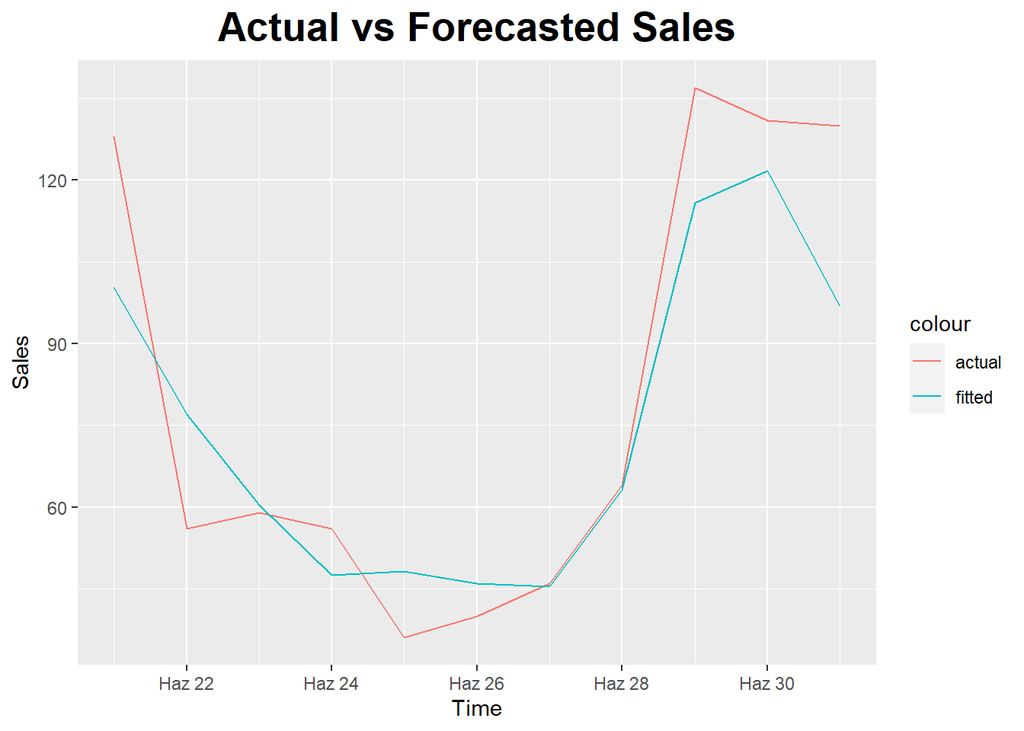

```r
ggplot(oralb_daily_te ,aes(x=event_date)) +
        geom_line(aes(y=sold_count,color='actual')) +
        geom_line(aes(y=forecastarimax,color='fitted')) + labs(title = "Actual vs Forecasted Sales",
       x = "Time",
       y = "Sales"
       )+
  theme(plot.title = element_text(color = "black", size = 20, face = "bold", hjust = 0.5),
        plot.subtitle = element_text(size = 10, face = "bold", hjust = 0.5),
        plot.caption = element_text(face = "italic", hjust = 0))
```

Above plot shows the fitted values of the last model. Model fits well with the actual values.

# Trendyolmilla Bikini 1

## Decomposition

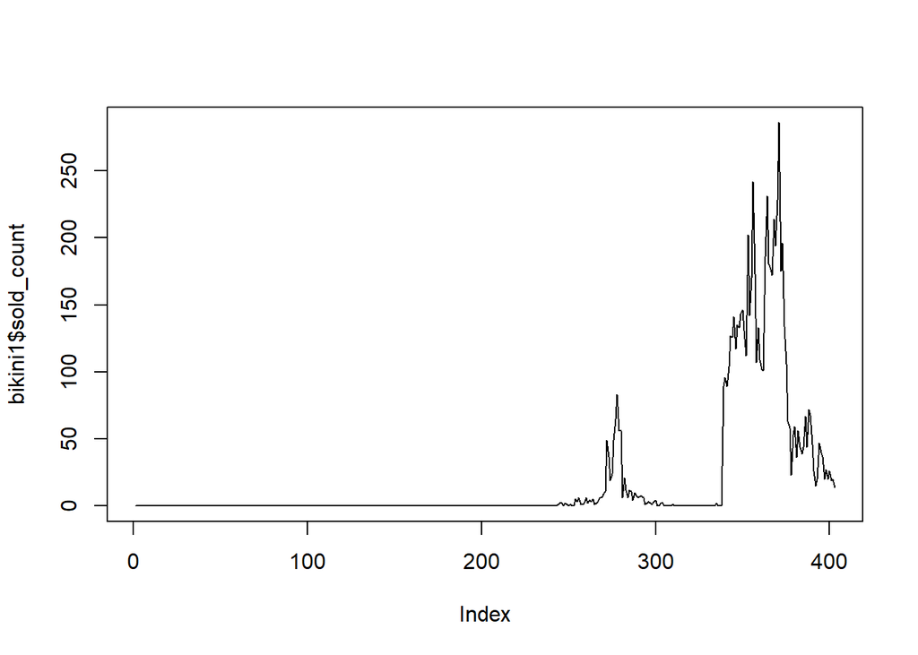

```r
bikini1<-subset(alldata, alldata$product_content_id==73318567)
bikini1_daily_tr<-bikini1[bikini1$event_date<"2021-06-21"]
bikini1_daily_te<-bikini1[bikini1$event_date>="2021-06-21"]
plot(bikini1$sold_count, type = 'l')
```

Plot above shows the sold count for bikini1. Sale volumes increased at summer and also there were sales at March

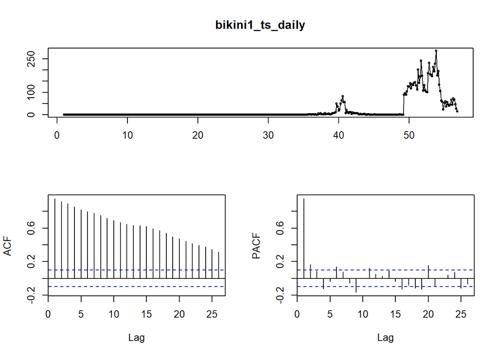

```r
bikini1_ts_daily<-ts(bikini1_daily_tr$sold_count, freq=7)
tsdisplay(bikini1_ts_daily)
```

Autocorrelation values are decreasing and PACF shows significant correlation at lag1.

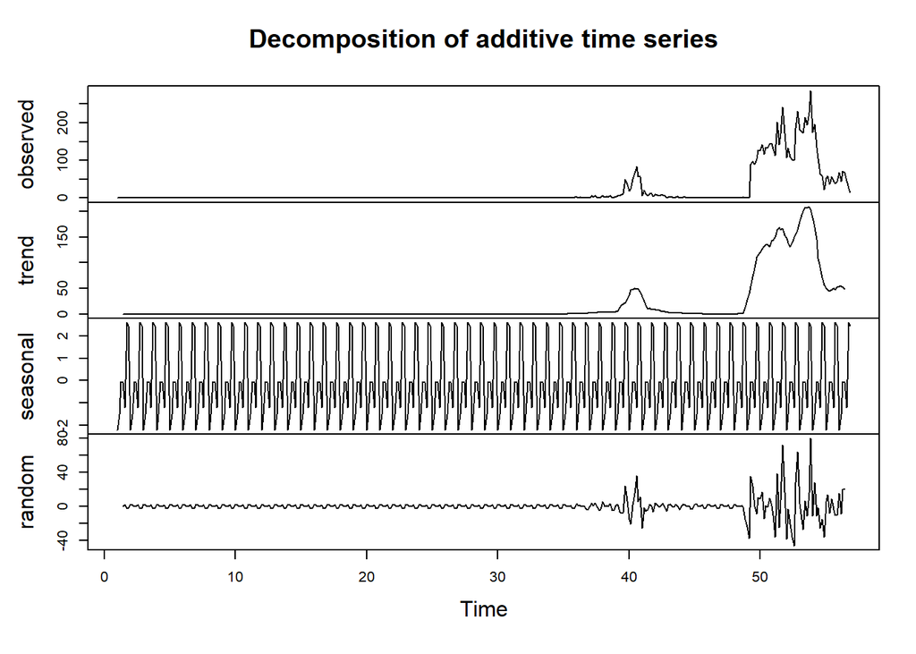

```r
bikini1_daily_additive<-decompose(bikini1_ts_daily, type ="additive")
bikini1_daily_multiplicative<-decompose(bikini1_ts_daily, type ="multiplicative")
plot(bikini1_daily_additive)
```

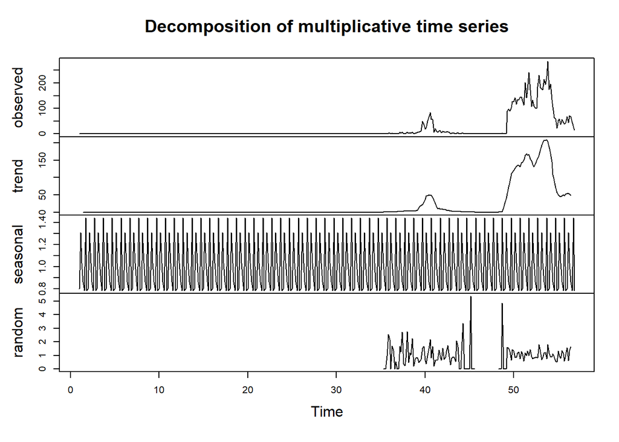

```r
plot(bikini1_daily_multiplicative)
```

Constant variance assumption is violated in both case In order to understand which model is better, the method to be used in the continuation of the study can be decided by applying specific tests that can measure stationarity for random part.

```r
test1=ur.kpss(bikini1_daily_additive$random, use.lag="7")
summary(test1)
```

```
##
## #######################
## # KPSS Unit Root Test #
## #######################
##
## Test is of type: mu with 7 lags.
##
## Value of test-statistic is: 0.0259
##
## Critical value for a significance level of:
##                 10pct  5pct 2.5pct  1pct
## critical values 0.347 0.463  0.574 0.739
```

```r
test2=ur.kpss(bikini1_daily_multiplicative$random, use.lag="7")
summary(test2)
```

```
##
## #######################
## # KPSS Unit Root Test #
## #######################
##
## Test is of type: mu with 7 lags.
##
## Value of test-statistic is: 0.1168
##
## Critical value for a significance level of:
##                 10pct  5pct 2.5pct  1pct
## critical values 0.347 0.463  0.574 0.739
```

Test statistic of additivie decomposition resulted better, therefore it is chosen for further examination.

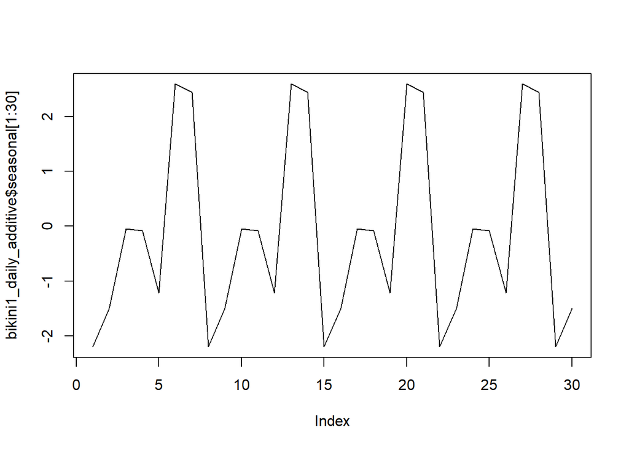

```r
plot(bikini1_daily_additive$seasonal[1:30], type='l')
```

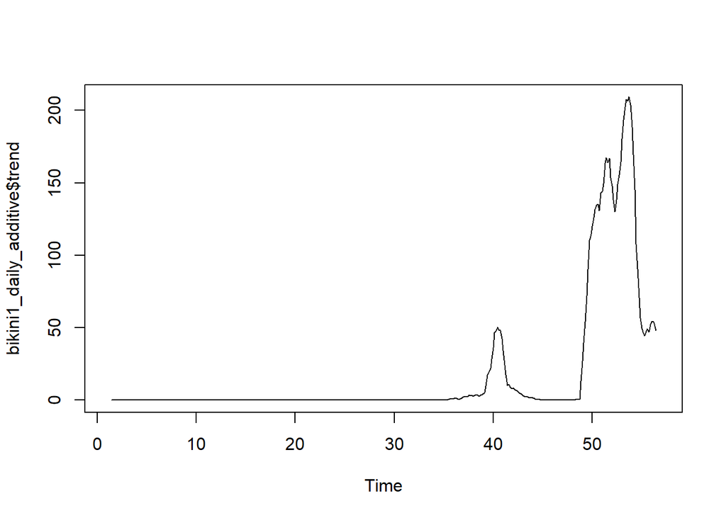

```r
plot(bikini1_daily_additive$trend, type='l')
```

Checking the seasonal component, we can clearly see seasonality in daily level. Plots above show closer looks for trend and seasonal components of additive decomposition. Since there are not enough data points, decomposition cannot made different levels. Altough we cannot decompose, weekly and monthly plots can be seen below.

Weekly

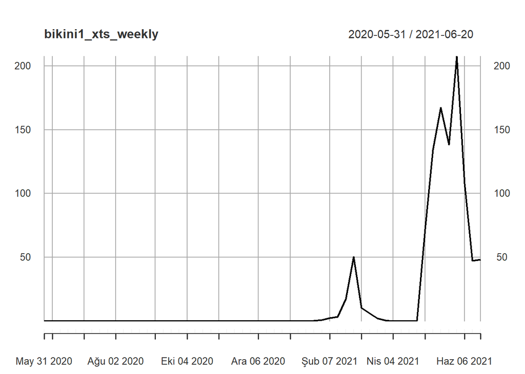

```r
bikini1_xts<-xts(bikini1_daily_tr$sold_count, order.by=as.Date(bikini1_daily_tr$event_date,"%d.%m.%Y"))
weekly<-endpoints(bikini1_xts,on="weeks")
bikini1_xts_weekly<-period.apply(bikini1_xts,INDEX=weekly,FUN=mean)
plot(bikini1_xts_weekly)
```

Monthly

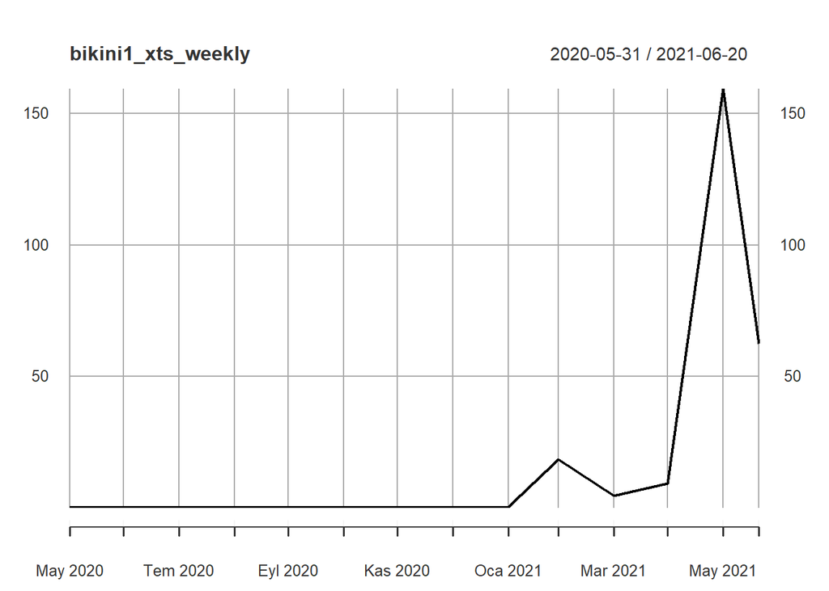

```r
bikini1_xts<-xts(bikini1_daily_tr$sold_count, order.by=as.Date(bikini1_daily_tr$event_date,"%d.%m.%Y"))
monthly<-endpoints(bikini1_xts,on="months")
bikini1_xts_weekly<-period.apply(bikini1_xts,INDEX=monthly,FUN=mean)
plot(bikini1_xts_weekly)
```

## ARIMA Model

To decide on the parameters of ARIMA model, autocorrelation and partial autocorrelation of the random component of additive model are investigated.

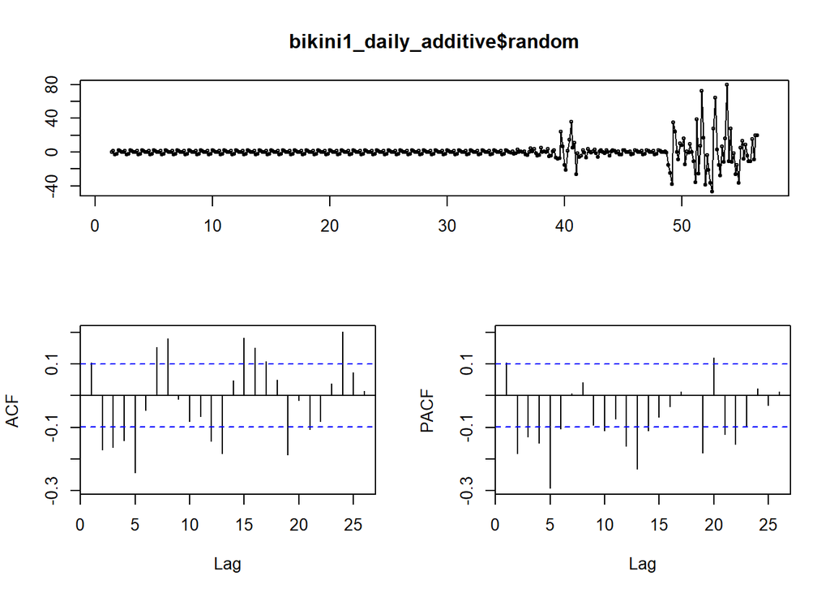

```r
tsdisplay(bikini1_daily_additive$random, na.action = na.omit)
```

```r
bikini1_model<-arima(bikini1_daily_additive$random, order = c(5,0,5))
summary(bikini1_model)
```

```
##
## Call:
## arima(x = bikini1_daily_additive$random, order = c(5, 0, 5))
##
## Coefficients:
##          ar1      ar2      ar3     ar4      ar5      ma1     ma2     ma3
##       0.1762  -0.3644  -0.4165  0.5881  -0.3656  -0.2840  0.0761  0.1389
## s.e.  0.1465   0.0546   0.0638  0.0727   0.0997   0.1591  0.0623  0.0520
##           ma4     ma5  intercept
##       -0.9411  0.0101     0.0003
## s.e.   0.0551  0.1546     0.0099
##
## sigma^2 estimated as 77.51:  log likelihood = -1392.75,  aic = 2809.5
##
## Training set error measures:
##                       ME     RMSE      MAE       MPE     MAPE      MASE
## Training set -0.04492755 8.803879 3.927318 -37.79243 242.1186 0.6478351
##                     ACF1
## Training set -0.00013618
```

As can be seen from the graphs there is significant negative autocorrelation in lag 5 at ACF and partial autocorrelation decreased significantly after lag 5 in PACF therefore parameters would be selected as (5,0,5)

```r
bikini1_model2<-arima(bikini1_daily_additive$random, order = c(5,0,4))
AIC(bikini1_model2)
```

```
## [1] 2807.508
```

Model 2 is better in terms of AIC values, therefore it is chosen to construct the ARIMA model

Fitting the model

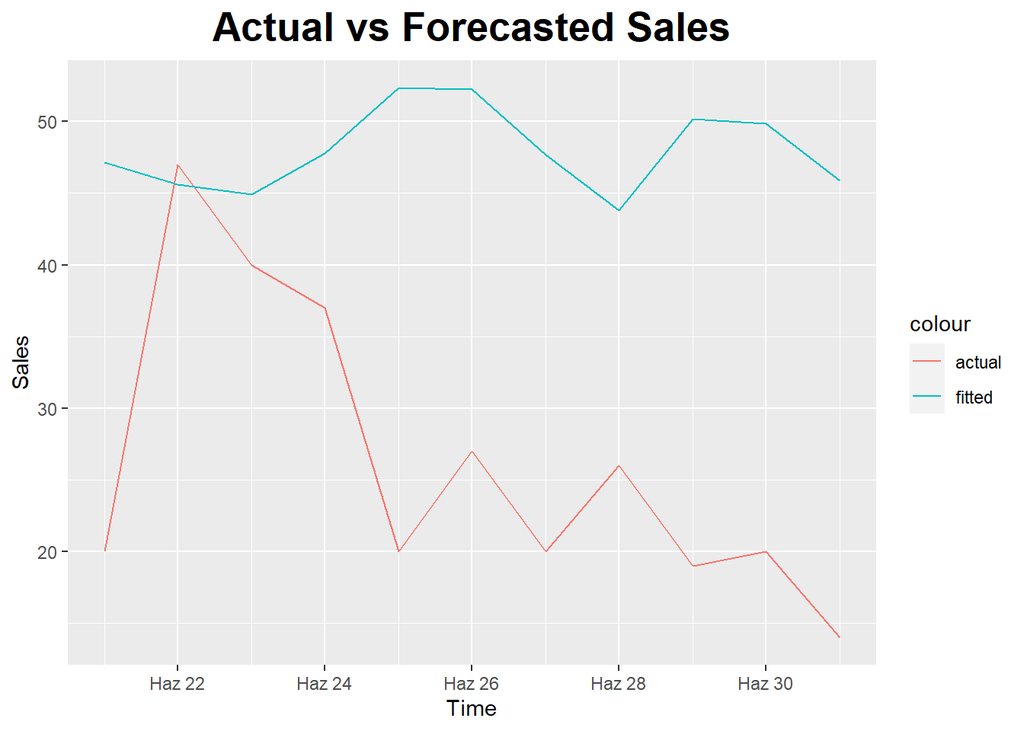

```r
model_forecast_error <- predict(bikini1_model2, n.ahead = 11)$pred
last_trend_value <-tail(bikini1_daily_additive$trend[!is.na(bikini1_daily_additive$trend)],1)
seasonality=bikini1_daily_additive$seasonal[295:305]
bikini1_arima_forecast=model_forecast_error+seasonality+last_trend_value

bikini1_daily_te$forecast<-paste(bikini1_arima_forecast)
bikini1_daily_te$forecast<-as.numeric(bikini1_daily_te$forecast)


ggplot(bikini1_daily_te ,aes(x=event_date)) +
        geom_line(aes(y=sold_count,color='actual')) +
        geom_line(aes(y=forecast,color='fitted')) + labs(title = "Actual vs Forecasted Sales",
       x = "Time",
       y = "Sales"
       )+
  theme(plot.title = element_text(color = "black", size = 20, face = "bold", hjust = 0.5),
        plot.subtitle = element_text(size = 10, face = "bold", hjust = 0.5),
        plot.caption = element_text(face = "italic", hjust = 0))
```

From above plot, it can be seen that we are overpredicting, it is mainly due to the constant trend assumption, with the addition of regressors this bias may be decreased.

```r
error_test(bikini1_daily_te$sold_count,bikini1_daily_te$forecast)
```

```
##    n     mean       sd       bias    mape      mad     wmape       MPE
## 1 11 26.36364 10.46205 -0.8187966 1.07578 21.83745 0.8283172 -1.070439
```

WMAPE value is too much in this case because of the reasons mentioned above.

## Regressor Search

To decide on which regressors to use, 3 different linear models are constructed and compared in terms of their error rates.

```r
bikini1_lm1<-lm(sold_count~price+is.discount_days, data=bikini1_daily_tr)
summary(bikini1_lm1)
```

```
##
## Call:
## lm(formula = sold_count ~ price + is.discount_days, data = bikini1_daily_tr)
##
## Residuals:
##    Min     1Q Median     3Q    Max
## -66.84 -62.22 -17.22  44.28 219.16
##
## Coefficients:
##                  Estimate Std. Error t value Pr(>|t|)
## (Intercept)      -196.957    842.376  -0.234   0.8156
## price               4.387     14.008   0.313   0.7547
## is.discount_days  -58.824     32.447  -1.813   0.0726 .
## ---
## Signif. codes:  0 '***' 0.001 '**' 0.01 '*' 0.05 '.' 0.1 ' ' 1
##
## Residual standard error: 70.76 on 108 degrees of freedom
##   (281 observations deleted due to missingness)
## Multiple R-squared:  0.03112,    Adjusted R-squared:  0.01318
## F-statistic: 1.735 on 2 and 108 DF,  p-value: 0.1814
```

```r
bikini1_lm2<-lm(sold_count~category_sold+price, data=bikini1_daily_tr)
summary(bikini1_lm2)
```

```
##
## Call:
## lm(formula = sold_count ~ category_sold + price, data = bikini1_daily_tr)
##
## Residuals:
##     Min      1Q  Median      3Q     Max
## -123.98  -28.98  -12.96   32.01  149.58
##
## Coefficients:
##                 Estimate Std. Error t value Pr(>|t|)
## (Intercept)    2.066e+03  7.208e+02   2.867  0.00499 **
## category_sold  2.333e-02  2.778e-03   8.399 1.95e-13 ***
## price         -3.425e+01  1.203e+01  -2.847  0.00529 **
## ---
## Signif. codes:  0 '***' 0.001 '**' 0.01 '*' 0.05 '.' 0.1 ' ' 1
##
## Residual standard error: 55.87 on 108 degrees of freedom
##   (281 observations deleted due to missingness)
## Multiple R-squared:  0.3961, Adjusted R-squared:  0.3849
## F-statistic: 35.42 on 2 and 108 DF,  p-value: 1.487e-12
```

```r
bikini1_lm3<-lm(sold_count~favored_count+basket_count, data=bikini1_daily_tr)
summary(bikini1_lm3)
```

```
##
## Call:
## lm(formula = sold_count ~ favored_count + basket_count, data = bikini1_daily_tr)
##
## Residuals:
##     Min      1Q  Median      3Q     Max
## -64.828  -0.148  -0.148  -0.148  34.767
##
## Coefficients:
##                Estimate Std. Error t value Pr(>|t|)
## (Intercept)    0.148174   0.435072   0.341    0.734
## favored_count -0.015716   0.001207 -13.017   <2e-16 ***
## basket_count   0.247511   0.003448  71.790   <2e-16 ***
## ---
## Signif. codes:  0 '***' 0.001 '**' 0.01 '*' 0.05 '.' 0.1 ' ' 1
##
## Residual standard error: 8.003 on 389 degrees of freedom
## Multiple R-squared:  0.9719, Adjusted R-squared:  0.9717
## F-statistic:  6721 on 2 and 389 DF,  p-value: < 2.2e-16
```

```r
bikini1_daily_te$forecastlm1<-predict(bikini1_lm1,bikini1_daily_te)
bikini1_daily_te$forecastlm2<-predict(bikini1_lm2,bikini1_daily_te)
bikini1_daily_te$forecastlm3<-predict(bikini1_lm3,bikini1_daily_te)

error_test(bikini1_daily_te$sold_count,bikini1_daily_te$forecastlm1)
```

```
##    n     mean       sd      bias     mape      mad    wmape       MPE
## 1 11 26.36364 10.46205 -1.511946 1.846804 39.86038 1.511946 -1.846804
```

```r
error_test(bikini1_daily_te$sold_count,bikini1_daily_te$forecastlm2)
```

```
##    n     mean       sd      bias     mape      mad    wmape       MPE
## 1 11 26.36364 10.46205 -4.673931 5.616296 123.2218 4.673931 -5.616296
```

```r
error_test(bikini1_daily_te$sold_count,bikini1_daily_te$forecastlm3)
```

```
##    n     mean       sd       bias      mape      mad     wmape        MPE
## 1 11 26.36364 10.46205 0.04327184 0.2039842 5.068131 0.1922395 0.02200445
```

## ARIMAX Model

```r
bikini1_xreg1<-cbind(bikini1_daily_tr$favored_count,
                  bikini1_daily_tr$basket_count)
bikini1_xreg2<-cbind(bikini1_daily_te$favored_count,
                  bikini1_daily_te$basket_count)

bikini1_arimax<-Arima(bikini1_ts_daily,xreg=as.matrix(bikini1_xreg1),order=c(3,0,3))
bikini1_daily_te$forecastarimax<-forecast(bikini1_arimax,xreg=as.matrix(bikini1_xreg2))$mean
error_test(bikini1_daily_te$sold_count,bikini1_daily_te$forecastarimax)
```

```
##    n     mean       sd       bias      mape      mad     wmape         MPE
## 1 11 26.36364 10.46205 0.02295718 0.2159454 5.033602 0.1909297 0.005587715
```

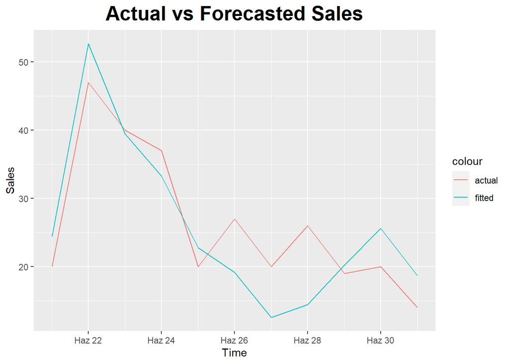

```r
ggplot(bikini1_daily_te ,aes(x=event_date)) +
        geom_line(aes(y=sold_count,color='actual')) +
        geom_line(aes(y=forecastarimax,color='fitted')) + labs(title = "Actual vs Forecasted Sales",
       x = "Time",
       y = "Sales"
       )+
  theme(plot.title = element_text(color = "black", size = 20, face = "bold", hjust = 0.5),
        plot.subtitle = element_text(size = 10, face = "bold", hjust = 0.5),
        plot.caption = element_text(face = "italic", hjust = 0))
```

Above plot shows the fitted values of the last model. Model fits well with the actual values.

# Trendyolmilla Bikini 2

## Decomposition

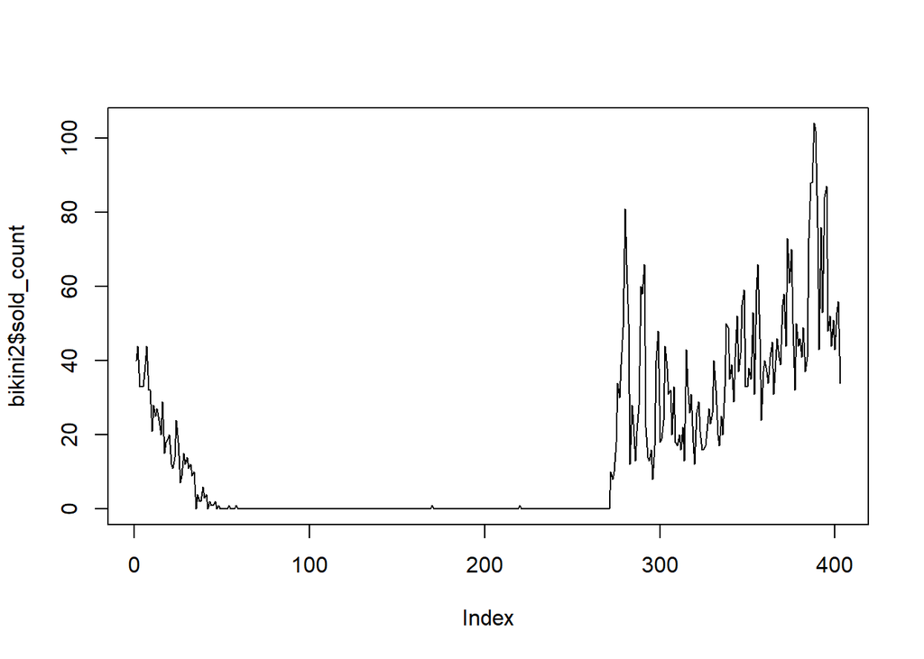

```r
bikini2<-subset(alldata, alldata$product_content_id==32737302)
#bikini2_xts<-xts(bikini2,order.by=bikini2$event_date)
bikini2_daily_tr<-bikini2[bikini2$event_date<"2021-06-21"]
bikini2_daily_te<-bikini2[bikini2$event_date>="2021-06-21"]
plot(bikini2$sold_count, type='l')
```

Plot above shows the sold counts for bikini2. Sales volumes shows a trend after January.

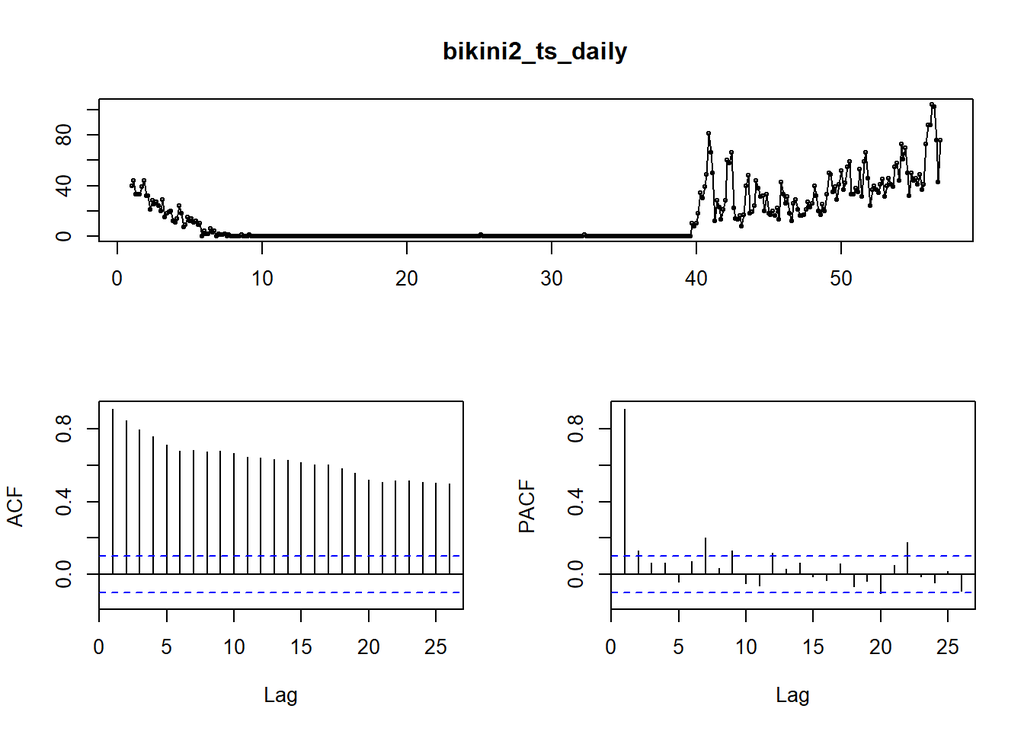

```r
bikini2_ts_daily<-ts(bikini2_daily_tr$sold_count, freq=7)
tsdisplay(bikini2_ts_daily)
```

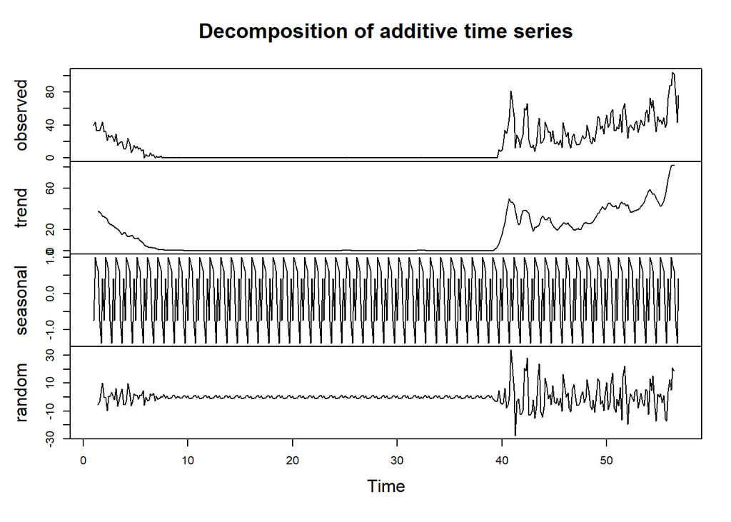

```r
bikini2_daily_additive<-decompose(bikini2_ts_daily, type ="additive")
bikini2_daily_multiplicative<-decompose(bikini2_ts_daily, type ="multiplicative")
plot(bikini2_daily_additive)
```

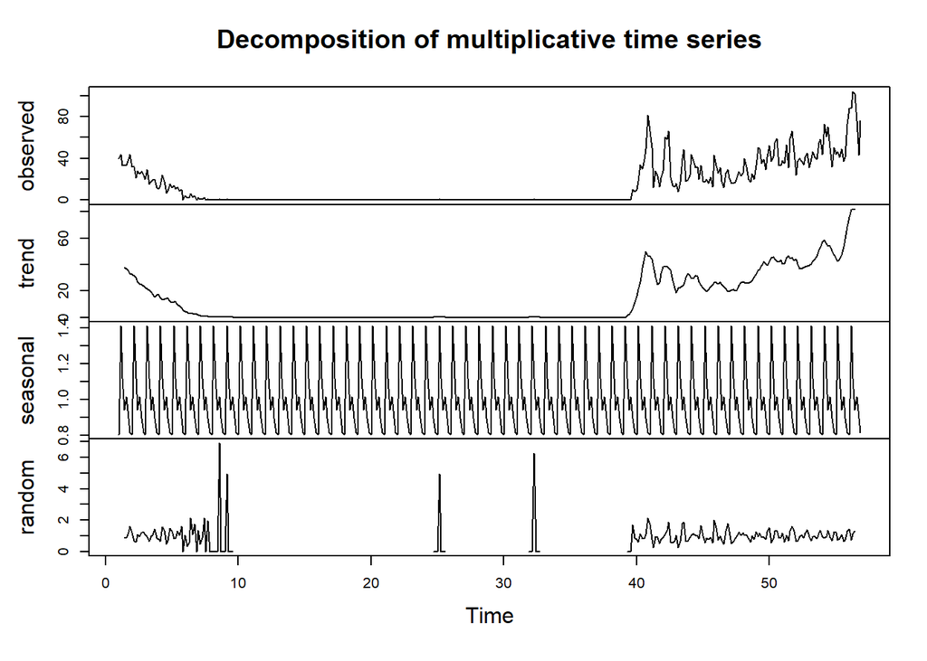

```r
plot(bikini2_daily_multiplicative)
```

For additive decomposition variance seems more constant comparing with the multiplicative decomposition. At multiplicative decomposition there is pikes at some days. The method to be used in the continuation of the study can be decided by applying specific tests that can measure stationarity for random part.

```r
test1=ur.kpss(bikini2_daily_additive$random, use.lag="7")
summary(test1)
```

```
##
## #######################
## # KPSS Unit Root Test #
## #######################
##
## Test is of type: mu with 7 lags.
##
## Value of test-statistic is: 0.0667
##
## Critical value for a significance level of:
##                 10pct  5pct 2.5pct  1pct
## critical values 0.347 0.463  0.574 0.739
```

```r
test2=ur.kpss(bikini2_daily_multiplicative$random, use.lag="7")
summary(test2)
```

```
##
## #######################
## # KPSS Unit Root Test #
## #######################
##
## Test is of type: mu with 7 lags.
##
## Value of test-statistic is: 0.122
##
## Critical value for a significance level of:
##                 10pct  5pct 2.5pct  1pct
## critical values 0.347 0.463  0.574 0.739
```

Additive decomposition resulted better in terms of the test statistic, therefore it is chosen for further examination

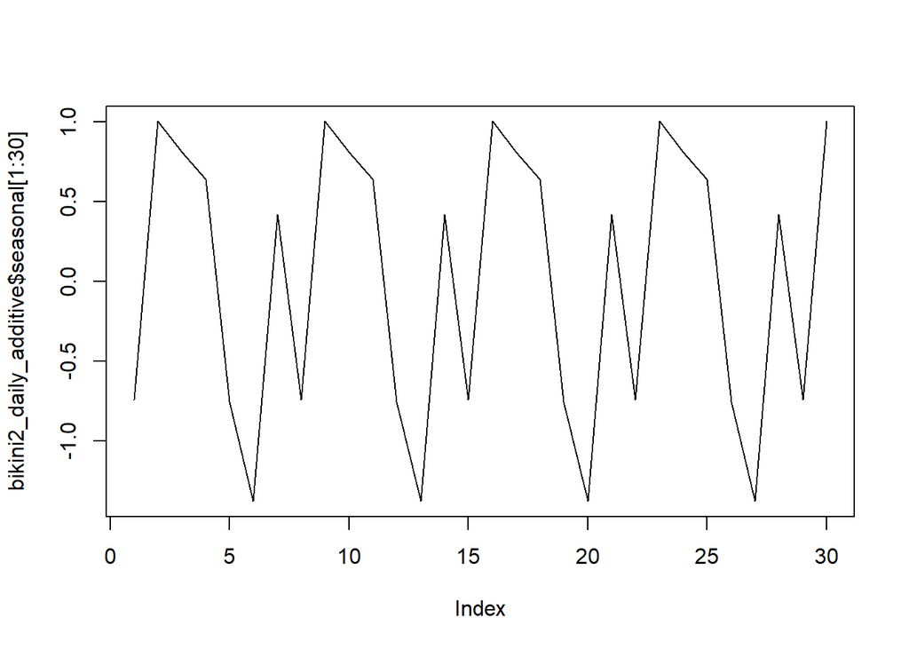

```r
plot(bikini2_daily_additive$seasonal[1:30], type='l')
```

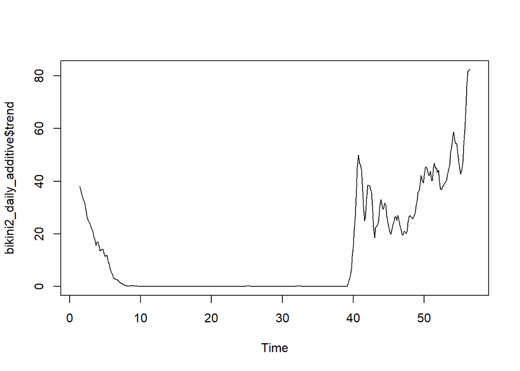

```r
plot(bikini2_daily_additive$trend, type='l')
```

Checking the seasonal component, we can clearly see seasonality in daily level. Plots above show closer looks for trend and seasonal components of additive decomposition. Since there are not enough data points, decomposition cannot made different levels. Altough we cannot decompose, weekly and monthly plots can be seen below.

Weekly

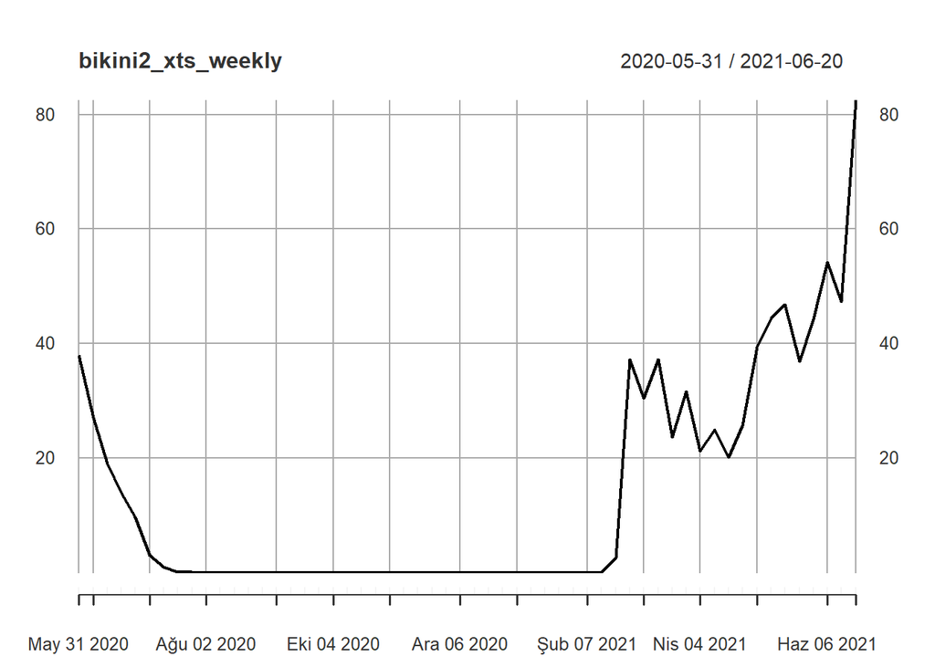

```r
bikini2_xts<-xts(bikini2_daily_tr$sold_count, order.by=as.Date(bikini2_daily_tr$event_date,"%d.%m.%Y"))
weekly<-endpoints(bikini2_xts,on="weeks")
bikini2_xts_weekly<-period.apply(bikini2_xts,INDEX=weekly,FUN=mean)
plot(bikini2_xts_weekly)
```

Monthly

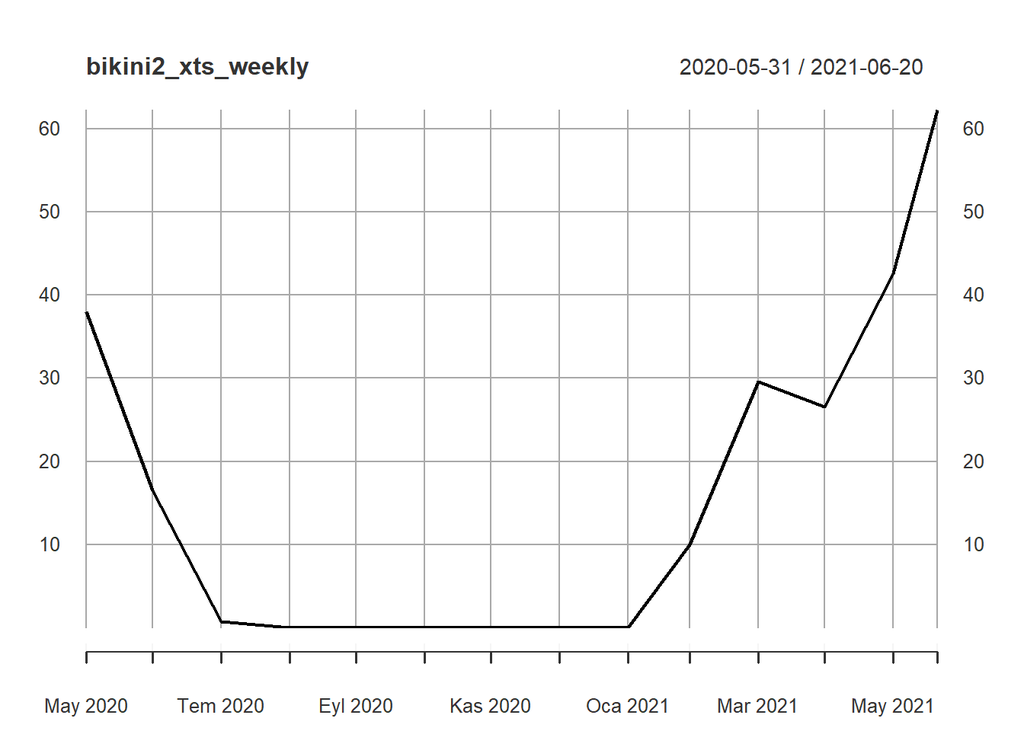

```r
bikini2_xts<-xts(bikini2_daily_tr$sold_count, order.by=as.Date(bikini2_daily_tr$event_date,"%d.%m.%Y"))
monthly<-endpoints(bikini2_xts,on="months")
bikini2_xts_weekly<-period.apply(bikini2_xts,INDEX=monthly,FUN=mean)
plot(bikini2_xts_weekly)
```

We can see the trend occurrence after January from both weekly and monthly transformed data.

## ARIMA Model

To decide on the parameters of ARIMA model, autocorrelation and partial autocorrelation of the random component of additive model are investigated.

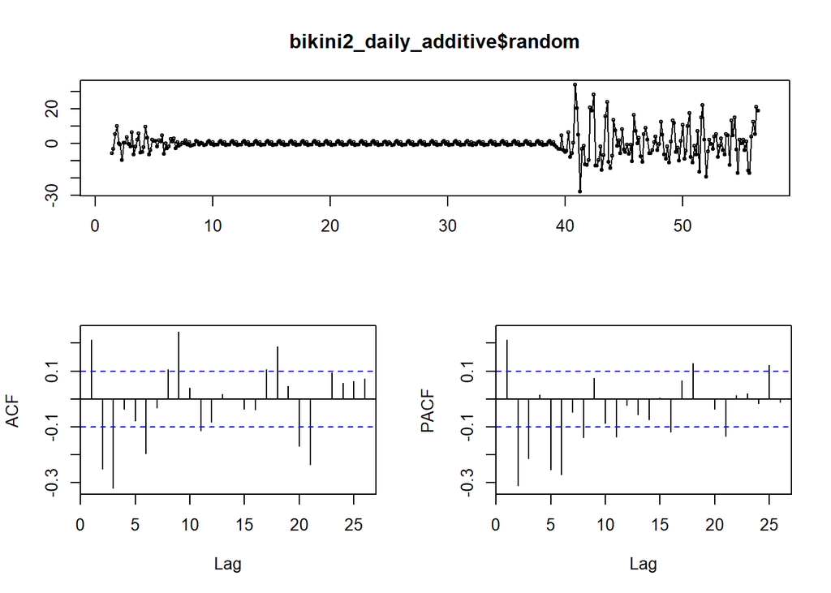

```r
tsdisplay(bikini2_daily_additive$random, na.action = na.omit)
```

```r
bikini2_model<-arima(bikini2_daily_additive$random, order = c(3,0,3))
summary(bikini2_model)
```

```
##
## Call:
## arima(x = bikini2_daily_additive$random, order = c(3, 0, 3))
##
## Coefficients:
##           ar1      ar2      ar3      ma1      ma2      ma3  intercept
##       -0.0022  -0.1073  -0.0801  -0.0176  -0.4037  -0.5787    -0.0061
## s.e.   0.1235   0.0785   0.0811   0.1174   0.0618   0.1070     0.0046
##
## sigma^2 estimated as 22.61:  log likelihood = -1152.51,  aic = 2321.03
##
## Training set error measures:
##                       ME     RMSE      MAE      MPE     MAPE      MASE
## Training set -0.05595952 4.755316 2.640292 74.72519 144.1095 0.6245488
##                     ACF1
## Training set -0.01022994
```

```r
bikini2_model2<-arima(bikini2_daily_additive$random, order = c(2,0,3))
AIC(bikini2_model2)
```

```
## [1] 2320.045
```

Model 2 is better in terms of AIC values, therefore it is chosen to construct the ARIMA model

Fitting the model

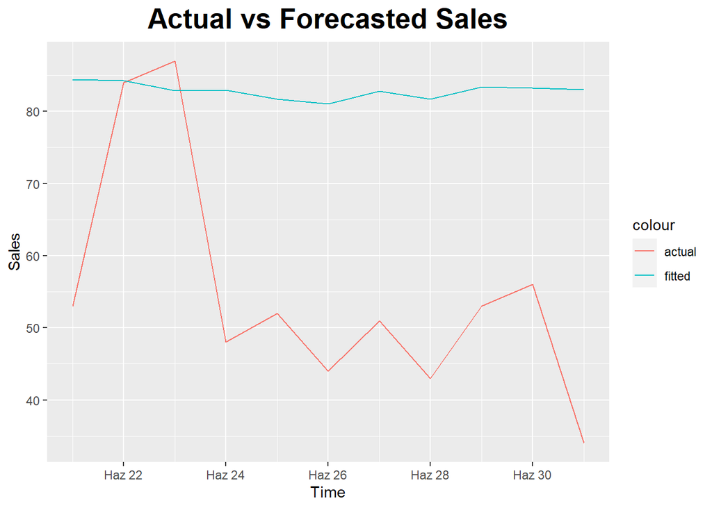

```r
model_forecast_error <- predict(bikini2_model2, n.ahead = 11)$pred
last_trend_value <-tail(bikini2_daily_additive$trend[!is.na(bikini2_daily_additive$trend)],1)
seasonality=bikini2_daily_additive$seasonal[295:305]
bikini2_arima_forecast=model_forecast_error+seasonality+last_trend_value

bikini2_daily_te$forecast<-paste(bikini2_arima_forecast)
bikini2_daily_te$forecast<-as.numeric(bikini2_daily_te$forecast)


ggplot(bikini2_daily_te ,aes(x=event_date)) +
        geom_line(aes(y=sold_count,color='actual')) +
        geom_line(aes(y=forecast,color='fitted')) + labs(title = "Actual vs Forecasted Sales",
       x = "Time",
       y = "Sales"
       )+
  theme(plot.title = element_text(color = "black", size = 20, face = "bold", hjust = 0.5),
        plot.subtitle = element_text(size = 10, face = "bold", hjust = 0.5),
        plot.caption = element_text(face = "italic", hjust = 0))
```

From above plot, it can be seen that we are overpredicting, it is mainly due to the constant trend assumption, with the addition of regressors this bias may be decreased.

```r
error_test(bikini2_daily_te$sold_count,bikini2_daily_te$forecast)
```

```
##    n mean      sd      bias      mape      mad    wmape        MPE
## 1 11   55 16.2911 -0.506666 0.6193516 28.61947 0.520354 -0.6106982
```

WMAPE value is too much in this case because of the reasons mentioned above.

## Regressor Search

To decide on which regressors to use, 3 different linear models are constructed and compared in terms of their error rates.

```r
bikini2_lm1<-lm(sold_count~price+is.discount_days, data=bikini2_daily_tr)
summary(bikini2_lm1)
```

```
##
## Call:
## lm(formula = sold_count ~ price + is.discount_days, data = bikini2_daily_tr)
##
## Residuals:
##    Min     1Q Median     3Q    Max
## -42.81 -14.97  -0.50  10.09  72.68
##
## Coefficients:
##                  Estimate Std. Error t value Pr(>|t|)
## (Intercept)       -51.198     62.497  -0.819    0.414
## price               1.370      1.039   1.318    0.189
## is.discount_days   12.834      9.283   1.383    0.169
##
## Residual standard error: 20.53 on 167 degrees of freedom
##   (222 observations deleted due to missingness)
## Multiple R-squared:  0.01545,    Adjusted R-squared:  0.003658
## F-statistic:  1.31 on 2 and 167 DF,  p-value: 0.2725
```

```r
bikini2_lm2<-lm(sold_count~category_sold+price, data=bikini2_daily_tr)
summary(bikini2_lm2)
```

```
##
## Call:
## lm(formula = sold_count ~ category_sold + price, data = bikini2_daily_tr)
##
## Residuals:
##     Min      1Q  Median      3Q     Max
## -41.575  -8.500  -0.676   8.639  44.648
##
## Coefficients:
##                 Estimate Std. Error t value Pr(>|t|)
## (Intercept)    1.266e+02  4.183e+01   3.027  0.00286 **
## category_sold  9.154e-03  6.948e-04  13.173  < 2e-16 ***
## price         -1.938e+00  7.044e-01  -2.751  0.00660 **
## ---
## Signif. codes:  0 '***' 0.001 '**' 0.01 '*' 0.05 '.' 0.1 ' ' 1
##
## Residual standard error: 14.46 on 167 degrees of freedom
##   (222 observations deleted due to missingness)
## Multiple R-squared:  0.5116, Adjusted R-squared:  0.5058
## F-statistic: 87.48 on 2 and 167 DF,  p-value: < 2.2e-16
```

```r
bikini2_lm3<-lm(sold_count~favored_count+basket_count, data=bikini2_daily_tr)
summary(bikini2_lm3)
```

```
##
## Call:
## lm(formula = sold_count ~ favored_count + basket_count, data = bikini2_daily_tr)
##
## Residuals:
##     Min      1Q  Median      3Q     Max
## -25.712  -0.063   0.159   0.159  35.205
##
## Coefficients:
##                Estimate Std. Error t value Pr(>|t|)
## (Intercept)   -0.159138   0.356595  -0.446    0.656
## favored_count -0.025855   0.002303 -11.225   <2e-16 ***
## basket_count   0.222054   0.005072  43.783   <2e-16 ***
## ---
## Signif. codes:  0 '***' 0.001 '**' 0.01 '*' 0.05 '.' 0.1 ' ' 1
##
## Residual standard error: 5.785 on 389 degrees of freedom
## Multiple R-squared:  0.9219, Adjusted R-squared:  0.9215
## F-statistic:  2294 on 2 and 389 DF,  p-value: < 2.2e-16
```

```r
bikini2_daily_te$forecastlm1<-predict(bikini2_lm1,bikini2_daily_te)
bikini2_daily_te$forecastlm2<-predict(bikini2_lm2,bikini2_daily_te)
bikini2_daily_te$forecastlm3<-predict(bikini2_lm3,bikini2_daily_te)

error_test(bikini2_daily_te$sold_count,bikini2_daily_te$forecastlm1)
```

```
##    n mean      sd      bias      mape      mad     wmape       MPE
## 1 11   55 16.2911 0.4185357 0.3798232 23.01947 0.4185357 0.3798232
```

```r
error_test(bikini2_daily_te$sold_count,bikini2_daily_te$forecastlm2)
```

```
##    n mean      sd       bias      mape      mad     wmape       MPE
## 1 11   55 16.2911 -0.1482096 0.3908551 20.80109 0.3782016 -0.242806
```

```r
error_test(bikini2_daily_te$sold_count,bikini2_daily_te$forecastlm3)
```

```
##    n mean      sd      bias     mape      mad     wmape       MPE
## 1 11   55 16.2911 0.1197114 0.127294 7.265821 0.1321058 0.1088184
```

## SARIMAX Model

```r
bikini2_xreg1<-cbind(bikini2_daily_tr$favored_count,
                  bikini2_daily_tr$basket_count)
bikini2_xreg2<-cbind(bikini2_daily_te$favored_count,
                  bikini2_daily_te$basket_count)

bikini2_arimax<-Arima(bikini2_ts_daily,xreg=as.matrix(bikini2_xreg1),order=c(2,0,2))
bikini2_daily_te$forecastarimax<-forecast(bikini2_arimax,xreg=as.matrix(bikini2_xreg2))$mean
error_test(bikini2_daily_te$sold_count,bikini2_daily_te$forecastarimax)
```

```
##    n mean      sd        bias      mape      mad     wmape         MPE
## 1 11   55 16.2911 0.005079662 0.1186635 6.154088 0.1118925 -0.02147385
```

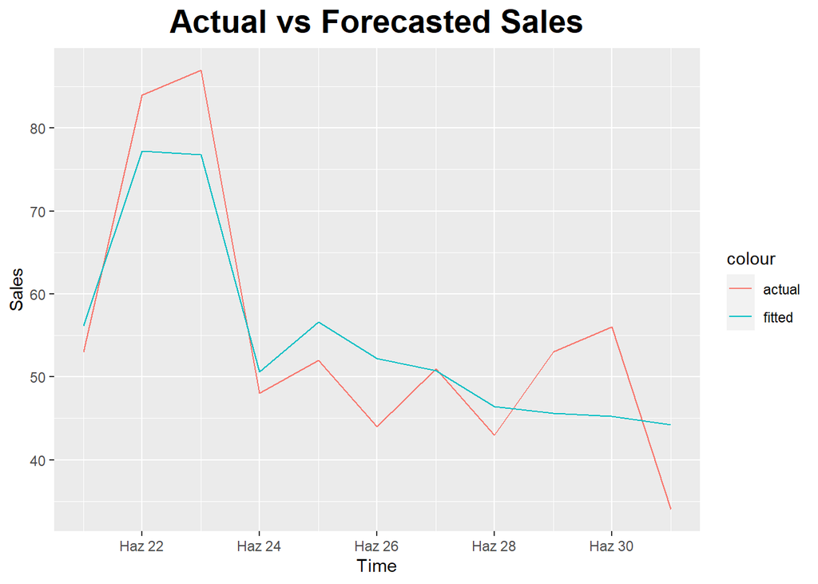

```r
ggplot(bikini2_daily_te ,aes(x=event_date)) +
        geom_line(aes(y=sold_count,color='actual')) +
        geom_line(aes(y=forecastarimax,color='fitted')) + labs(title = "Actual vs Forecasted Sales",
       x = "Time",
       y = "Sales"
       )+
  theme(plot.title = element_text(color = "black", size = 20, face = "bold", hjust = 0.5),
        plot.subtitle = element_text(size = 10, face = "bold", hjust = 0.5),
        plot.caption = element_text(face = "italic", hjust = 0))
```

Above plot shows the fitted values of the last model. Model fits well with the actual values.

# Trendyolmilla Tayt

## Decomposition

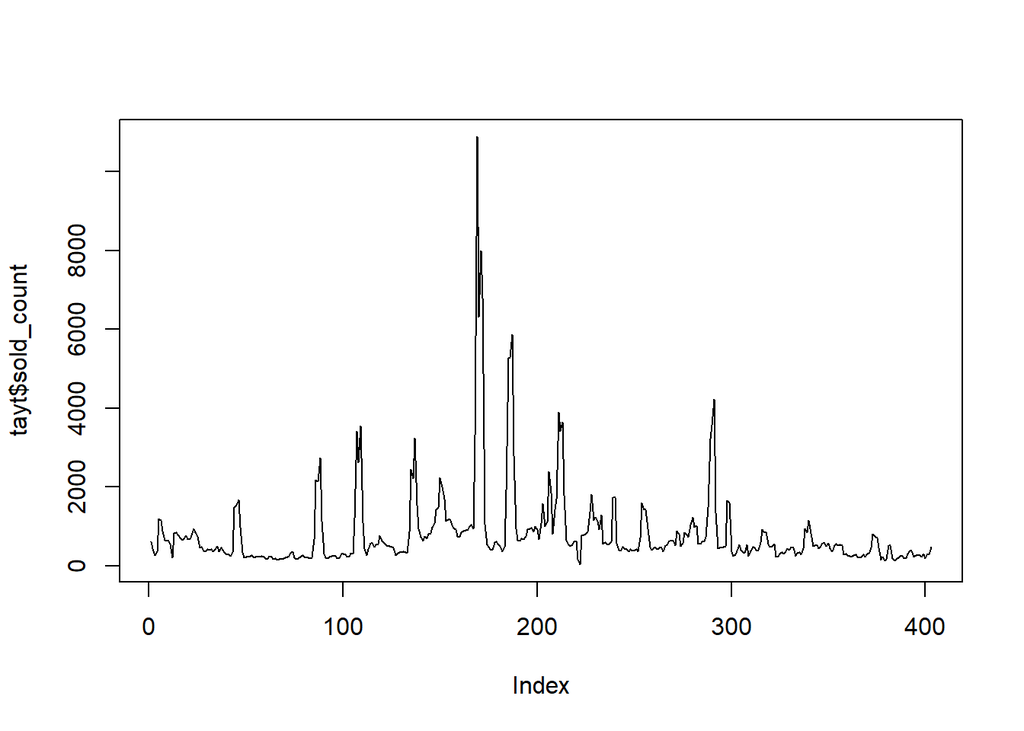

```r
tayt<-subset(alldata, alldata$product_content_id==31515569)
#tayt_xts<-xts(tayt,order.by=tayt$event_date)
tayt_daily_tr<-tayt[tayt$event_date<"2021-06-21"]
tayt_daily_te<-tayt[tayt$event_date>="2021-06-21"]
plot(tayt$sold_count, type='l')
```

Above plot shows the sales volumes for Trendyolmilla Tayt. Tayt has been sold for the whole year and there is some pikes at certain days.

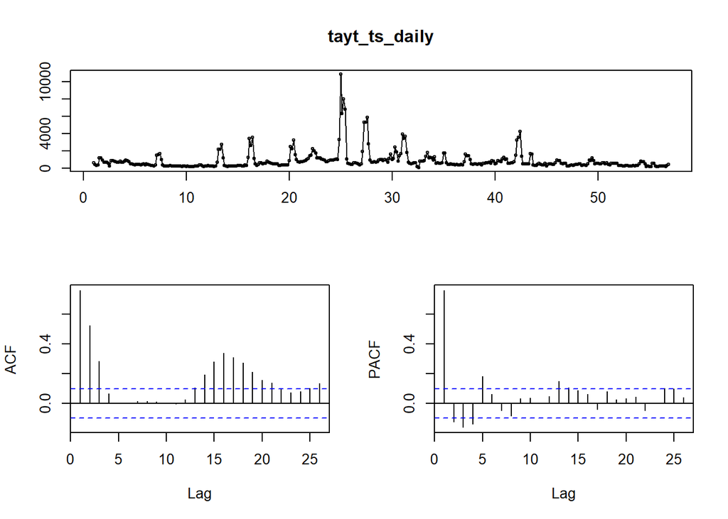

```r
tayt_ts_daily<-ts(tayt_daily_tr$sold_count, freq=7)
tsdisplay(tayt_ts_daily)
```

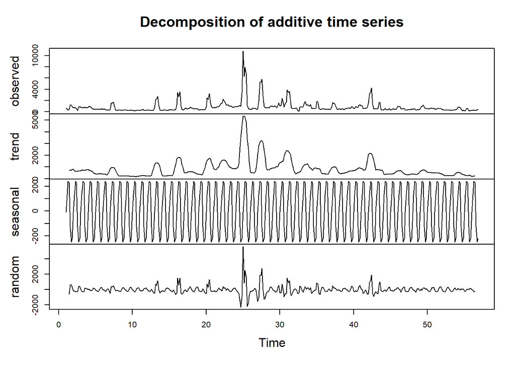

```r
tayt_daily_additive<-decompose(tayt_ts_daily, type ="additive")
tayt_daily_multiplicative<-decompose(tayt_ts_daily, type ="multiplicative")
plot(tayt_daily_additive)
```

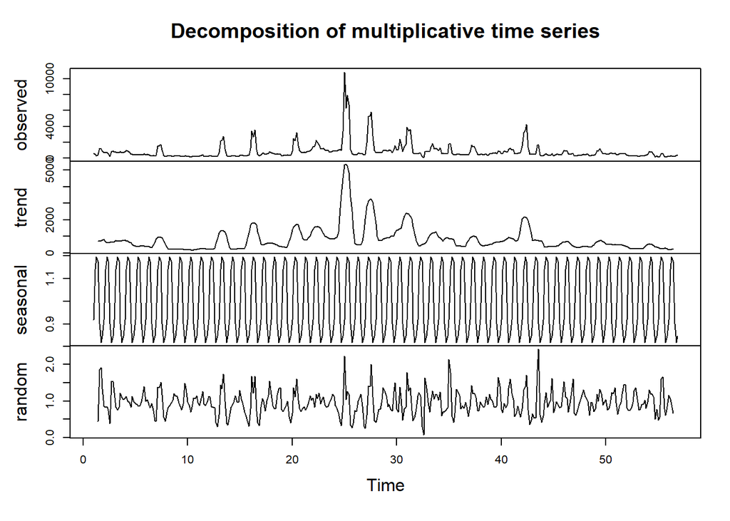

```r
plot(tayt_daily_multiplicative)
```

Above plots show trend, seasonal and random components of multiplicative and additive decomposition. There is pikes at certain days in additive decomposition and constant variance assumption is violated. For multiplicative decomposition variance is higher than the additive. The method to be used in the continuation of the study can be decided by applying specific tests that can measure stationarity for random part.

```r
test1=ur.kpss(tayt_daily_additive$random, use.lag="7")
summary(test1)
```

```
##
## #######################
## # KPSS Unit Root Test #
## #######################
##
## Test is of type: mu with 7 lags.
##
## Value of test-statistic is: 0.0126
##
## Critical value for a significance level of:
##                 10pct  5pct 2.5pct  1pct
## critical values 0.347 0.463  0.574 0.739
```

```r
test2=ur.kpss(tayt_daily_multiplicative$random, use.lag="7")
summary(test2)
```

```
##
## #######################
## # KPSS Unit Root Test #
## #######################
##
## Test is of type: mu with 7 lags.
##
## Value of test-statistic is: 0.1298
##
## Critical value for a significance level of:
##                 10pct  5pct 2.5pct  1pct
## critical values 0.347 0.463  0.574 0.739
```

Additive decomposition resulted better and is chosen to be used for futher examination.